# MFPCA & GAMM for UTI

Nathalie Elsässer

2025-07-18

This script was written using the help of three great tutorials – Gubian (2025); Coretta and Sakr (2025); Wieling (2018).

```r
# data processing and plotting
library(tidyverse)
library(plotly)
library(rticulate)
# GAMs
library(mgcv)
library(itsadug)
# FPCA
library(funData)
library(MFPCA)
# install.packages("devtools")
# devtools::install_github("uasolo/landmarkregUtils")
library(landmarkregUtils)
library(abind)
# LMER
library(lme4)
library(emmeans)
# plotting
library(RColorBrewer)
library(gridExtra)
source("polar_utils.R")
```

## static data

In this first part, we are using the static data that we created in the $data preparation$ steps.

Read in the cartesian static data set:

```r
rhotic_data_static <- readRDS("../data/RDS/rhotic_data_static.rds")
```

The important parts of the data set for this part of the script are: * $participant$: The data set contains the data of 8 participants. They are abbreviated by “vp” (*Versuchsperson*) plus their participant number. The participants included have the numbers 4, 5, 6, 8, 9, 10, 20 and 23 * $target$: The target words that were read by the participants * $knot$: Each tongue spline is defined by 11 knots. 0 is the knot closest to the tongue root, 10 is the knot closest to the tongue tip. * $frame\_id$: All knots on one tongue spline have the same $frame\_id$ to make clear that the rows in the table belong together. * $x\_mean$: The mean x-value of the target-/r/ of a participant * $y\_mean$: The mean y-value of the target-/r/ of a participant * $x\_mean\_z$: The mean x-value of the target-/r/ of a participant - z-scored * $y\_mean\_z$: The mean y-value of the target-/r/ of a participant - z-scored

The goal in this script is to find out if there are differences in the production of the rhotic between the different speakers – disregarding syllable position, phonetic environment or anything else.

### GAMM

GAMM is a generalized additive mixed model, for a general tutorial see Wieling (2018).

#### polar coordinates

Polar coordinates use a radius and an angle to define coordinates. The angle is a predictor variable used to predict the radius (radius = f(angle)).

Load the data:

```r
rhotic_data_static_polar <- readRDS("../data/RDS/rhotic_data_polar_static.rds")
```

The data set looks the same as the cartesian data set described above but instead of x_mean- and y_mean-values, it has angle- and radius-values. [Note: I will call this data the “original” polar data (in comparison to the linear/procrustean normalized data), but in reality, this data is not the “original”/raw data that we got from AAA, but data that was first z-scored as cartesian coordinates and then (after the z-scoring) converted to polar coordinates.]

If we plot the polar data in a cartesian coordinate system with angle on the x-axis and radius on the y-axis, it looks like this:

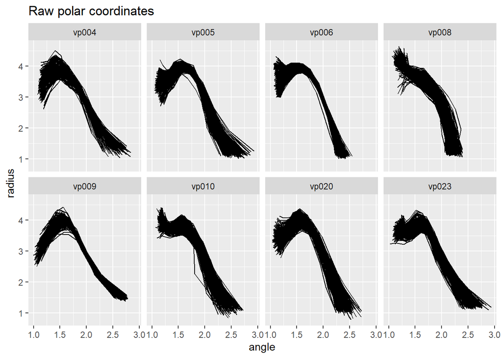

```r
# plot raw polar
ggplot(rhotic_data_static_polar) +
  aes(angle, radius, group = frame_id) +
  geom_path() +
  ggtitle("Raw polar coordinates") +
  facet_wrap(vars(participant), ncol = 4)
```

Note that the plots here are mirrored in comparison to what we’re normally used to when looking at tongue splines - the tongue tip is pictured on the left side (small angle values) while the tongue root is on the right side.

In a polar coordinate system, the data looks like this:

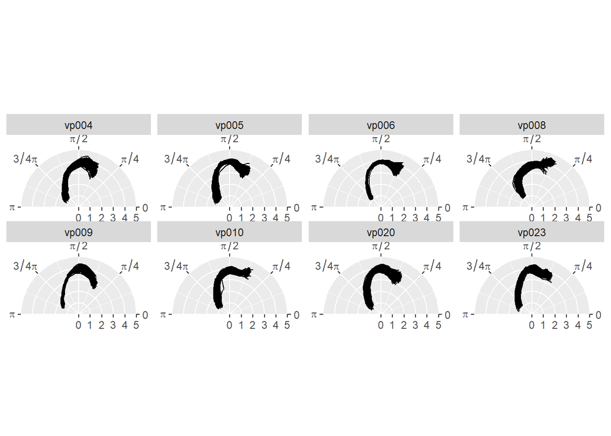

```r
ggplot(rhotic_data_static_polar) +
    aes(angle, radius, group = frame_id) +
    geom_path() +
    radial_plot(5) +
  facet_wrap(vars(participant), ncol = 4)
```

(Here the tongue tip is pictures on the right side, tongue root on the left side.)

As input formula for the GAM, we take the basic formula `radius ~ angle` – angle is the independent variable while radius is the dependent variable. We want to predict radius given the two predictors angle and participant.

```r
polar_gam_static <- bam(radius ~ participant + s(angle, by = factor(participant)),
                          discrete = TRUE,
                        family = 'scat',
                        data = rhotic_data_static_polar
)
AR1.rho <- acf_resid(polar_gam_static)[2]
```

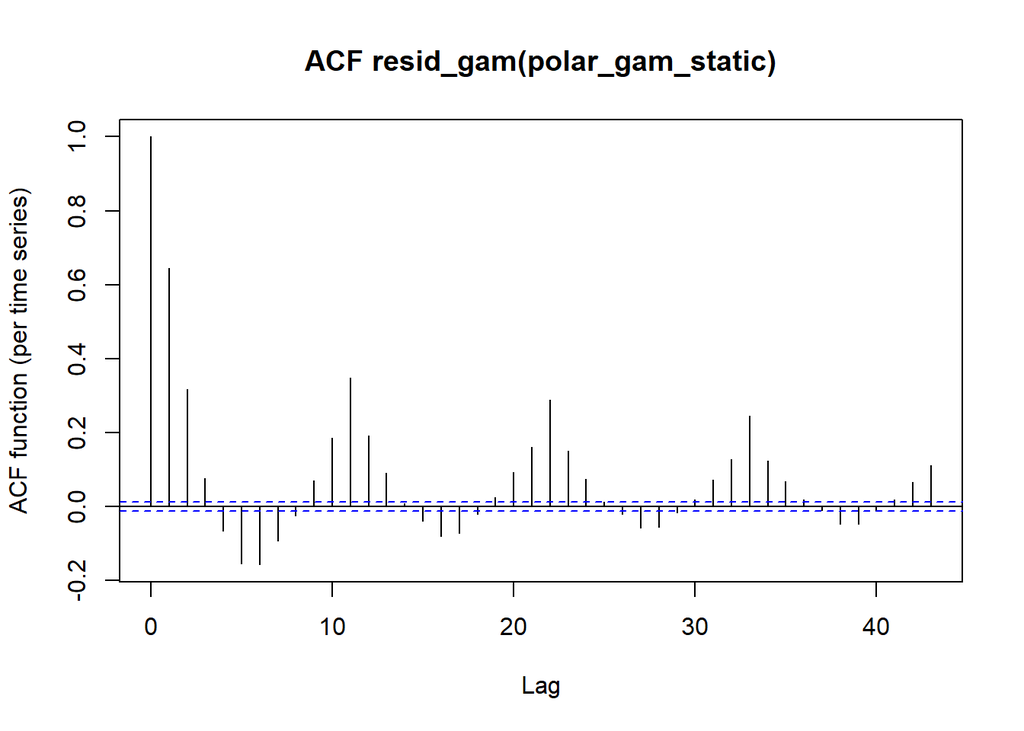

Taking autocorrelation into account (see Wieling (2018)):

```r
polar_gam_static <- bam(radius ~ participant + s(angle, by = factor(participant)),
                          discrete = TRUE,
                        family = 'scat',
                        rho = AR1.rho,
                        AR.start = rhotic_data_static_polar %>% pull(knot) == 0,
                        data = rhotic_data_static_polar
)
summary(polar_gam_static)
```

```
##
## Family: Scaled t(3.705,0.129)
## Link function: identity
##
## Formula:
## radius ~ participant + s(angle, by = factor(participant))
##
## Parametric coefficients:
##                   Estimate Std. Error t value Pr(>|t|)
## (Intercept)       2.746881   0.007584 362.208  < 2e-16 ***
## participantvp005 -0.028923   0.009283  -3.116  0.00184 **
## participantvp006  0.162864   0.061143   2.664  0.00773 **
## participantvp008  0.518336   0.184062   2.816  0.00487 **
## participantvp009  0.070869   0.011227   6.313 2.79e-10 ***
## participantvp010 -0.029893   0.010388  -2.878  0.00401 **
## participantvp020 -0.051071   0.010850  -4.707 2.53e-06 ***
## participantvp023  0.028415   0.009264   3.067  0.00216 **
## ---
## Signif. codes:  0 '***' 0.001 '**' 0.01 '*' 0.05 '.' 0.1 ' ' 1
##
## Approximate significance of smooth terms:
##                                     edf Ref.df    F p-value
## s(angle):factor(participant)vp004 8.761  8.976 3160  <2e-16 ***
## s(angle):factor(participant)vp005 8.942  8.999 7844  <2e-16 ***
## s(angle):factor(participant)vp006 8.548  8.805 7741  <2e-16 ***
## s(angle):factor(participant)vp008 8.014  8.105 7063  <2e-16 ***
## s(angle):factor(participant)vp009 8.675  8.934 3169  <2e-16 ***
## s(angle):factor(participant)vp010 8.740  8.953 7168  <2e-16 ***
## s(angle):factor(participant)vp020 8.886  8.990 7790  <2e-16 ***
## s(angle):factor(participant)vp023 8.953  8.999 7255  <2e-16 ***
## ---
## Signif. codes:  0 '***' 0.001 '**' 0.01 '*' 0.05 '.' 0.1 ' ' 1
##
## R-sq.(adj) =  0.955   Deviance explained = 79.6%
## fREML =  33434  Scale est. = 1         n = 23782
```

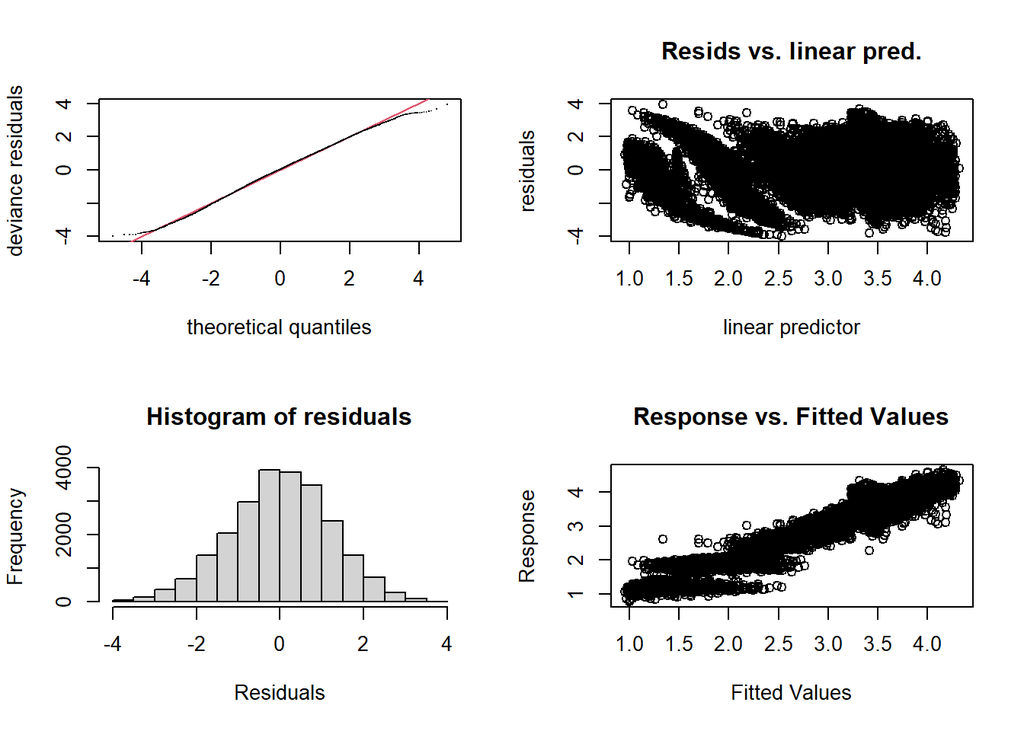

```
##
## Method: fREML   Optimizer: perf chol
## $grad
## [1] -1.368239e-12 -1.533440e-12 -6.668464e-09  2.148993e-07 -9.403145e-12
## [6]  8.872458e-12  1.278155e-10 -2.557954e-13
##
## $hess
##               [,1]          [,2]          [,3]          [,4]          [,5]
## [1,]  3.918118e+00 -3.750724e-19  1.675770e-16 -2.339166e-16  1.097608e-18
## [2,] -1.822345e-19  3.978892e+00 -4.492543e-26 -8.948169e-26 -8.945874e-29
## [3,]  7.856680e-17 -3.736183e-26  1.435157e+00 -4.025470e-24  6.310605e-26
## [4,]  1.089544e-16 -2.639781e-25  4.327519e-24  2.458447e+00  9.669028e-25
## [5,]  2.252950e-18 -9.091166e-29  2.764044e-26  6.545517e-25  3.686889e+00
## [6,] -3.239154e-18  1.672013e-28 -2.258080e-25 -9.317758e-25 -8.825686e-28
## [7,] -3.038387e-18 -3.221379e-28  8.349492e-25  1.427397e-24  1.512381e-27
## [8,] -5.752330e-19 -5.433929e-29  1.056613e-25  3.293666e-25  3.292672e-28
##               [,6]          [,7]          [,8]
## [1,]  1.080933e-18 -5.259992e-18  5.218574e-19
## [2,]  1.535996e-28 -2.533591e-28 -5.613580e-29
## [3,] -2.489942e-25  6.621571e-25  3.368090e-26
## [4,] -6.990492e-25 -1.351085e-24  3.863223e-25
## [5,] -7.747411e-28  1.431128e-27  3.283242e-28
## [6,]  3.794914e+00 -6.650192e-27 -5.341705e-28
## [7,] -4.173169e-27  3.787963e+00  8.954926e-28
## [8,] -5.249877e-28  8.346517e-28  3.961696e+00
##
## Model rank =  80 / 80
##
## Basis dimension (k) checking results. Low p-value (k-index<1) may
## indicate that k is too low, especially if edf is close to k'.
##
##                                     k'  edf k-index p-value
## s(angle):factor(participant)vp004 9.00 8.76    0.94  <2e-16 ***
## s(angle):factor(participant)vp005 9.00 8.94    0.94  <2e-16 ***
## s(angle):factor(participant)vp006 9.00 8.55    0.94  <2e-16 ***
## s(angle):factor(participant)vp008 9.00 8.01    0.94  <2e-16 ***
## s(angle):factor(participant)vp009 9.00 8.68    0.94  <2e-16 ***
## s(angle):factor(participant)vp010 9.00 8.74    0.94  <2e-16 ***
## s(angle):factor(participant)vp020 9.00 8.89    0.94  <2e-16 ***
## s(angle):factor(participant)vp023 9.00 8.95    0.94  <2e-16 ***
## ---
## Signif. codes:  0 '***' 0.001 '**' 0.01 '*' 0.05 '.' 0.1 ' ' 1
```

```r
gam.check(polar_gam_static)
```

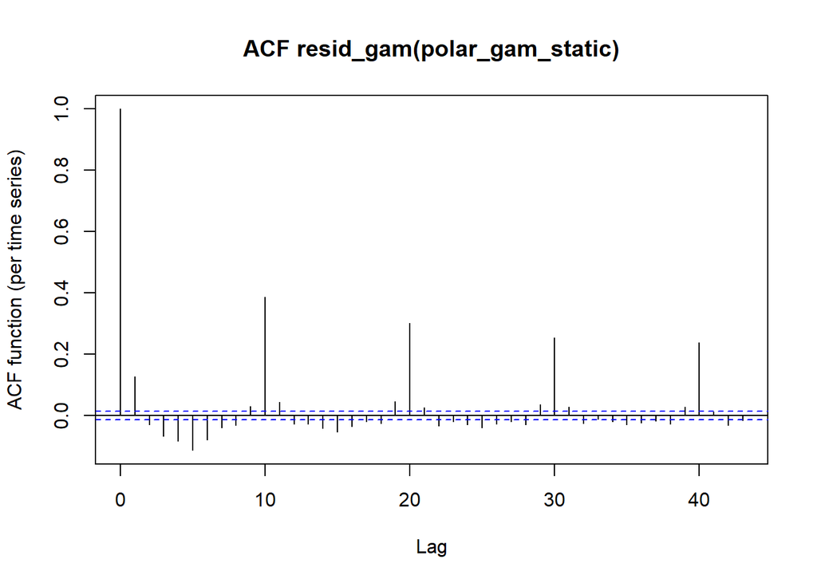

```r
acf_resid(polar_gam_static)
```

Now that we’ve calculated the GAM, we get the predictions and plot them:

```r
angle_grid_plot <- seq(min(rhotic_data_static_polar$angle), max(rhotic_data_static_polar$angle),
                       length.out = 20) # make a prediction plot with 20 values
static_polar_pred <- get_predictions(polar_gam_static,
                        cond = list(angle = angle_grid_plot,
                                    participant = factor(rhotic_data_static_polar$participant) %>% levels()),
                        print.summary = FALSE)

gam_polar_plot <- ggplot(static_polar_pred) +
  aes(x = angle, y = fit, group = participant ) +
  geom_line(mapping = aes(color = participant)) +
  # scale_color_manual(values=Category.colors) +
  # scale_fill_manual(values=Category.colors) +
  geom_ribbon(mapping = aes(ymin = fit - CI, ymax = fit + CI, fill = participant), alpha = 0.5) +
  radial_plot(10) +
  theme(legend.position = "bottom")
```

Plot the predictions:

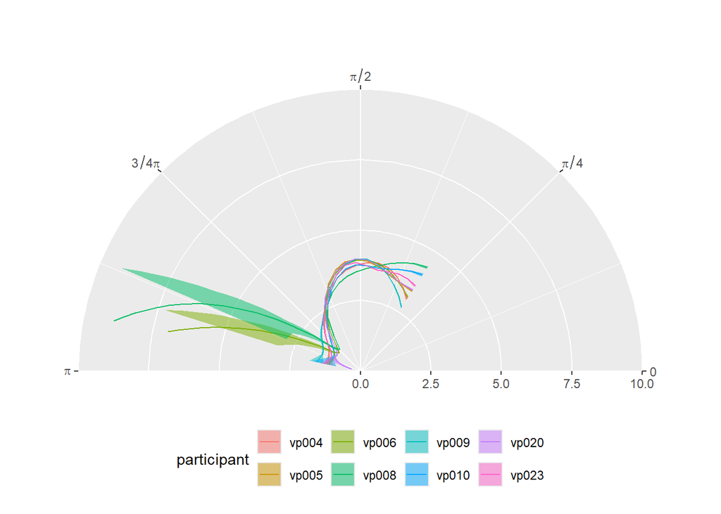

```r
gam_polar_plot
```

The shapes of the predicted contours of the different participants itself seem to fit the data well when comparing with the original splines from the participants. Participant 8 shows the highest tongue tip while participant 9 shows the most bend downward tongue tip. Also, there is variation in the area around the tongue dorsum – while participant 8 has a very flat tongue dorsum, most other partcipants show a raised tongue dorsum.

But it seems like there is something wrong with the very left side of the data – so the values at the tongue root. Especially for participants 6 and 8 it seems like there is something wrong. It might be the case that there are not enough data points to calculate proper splines at angle values of 7/8$\pi$ and higher? A similar problem occured in Gubian (2025) (UTI_analysis_code.html#sec-st_angle_GAM). The suggestions there are to do a linear angle normalization and a Procrustean fit (“we establish a fixed angle range for all contours, cut off the points that are beyond that range and extrapolate points for contours that do not have values up to the range limits”, Gubian (2025)). We will try both of these methods and see what they change about this data set and if the predicted values at the tongue root make more sense then.

##### Linear Angle Normalization

We will now do a linear angle normalization similar to what Gubian (2025) describes:

“A simple way to establish the reference angle range is to take the median angle of the first/last point from all contours. The contours are then reinterpolated on a regular grid within the common angle range. This of course introduces approximations, including the fact that now knots lose their original interpretation.” (Gubian 2025)

```r
angle_range <- rhotic_data_static_polar  %>%
  filter(knot %in% range(knot)) %>% # first and last knot
  group_by(knot) %>%
  summarise(median_angle = median(angle)) %>% # median angle for first and last knot (all participants)
  pull(median_angle) %>%
  sort()

angle_grid <- seq(angle_range[1], angle_range[2], length.out=11) # 11 equidistant points between the median of knot0 & knot11

linear_norm_static_polar_curves  <- rhotic_data_static_polar  %>%
  group_by(participant, frame_id) %>%
  # linear angle normalization on the angle_range interval
  mutate(angle = (angle - min(angle)) * diff(angle_range) / diff(range(angle)) + angle_range[1]) %>%
  # linear interpolation on angle_grid (optional for GAM)
  reframe(bind_cols(
    knot = seq(along.with = angle_grid, from = 0), # fake knots, needed for AR1 term in GAM; knots have no meaning
    approx(angle, radius, angle_grid) %>% as_tibble() # returns list of points which linearly interpolate given data points
    )) %>%
  rename(angle = x, radius = y)
```

Comparison of the old data set and the linear angle normalized data set:

```r
polar_plot_z_per_part <- ggplot(rhotic_data_static_polar) +
    aes(angle, radius, group = frame_id, color = participant) +
    geom_path() +
    ggtitle("OG data") +
    radial_plot(5) +
    theme(legend.position = "bottom") + facet_wrap(vars(participant), ncol = 3)
polar_plot_linear_norm <- ggplot(linear_norm_static_polar_curves) +
    aes(angle, radius, group = frame_id, color = participant) +
    geom_path() +
    ggtitle("linear norm data") +
    radial_plot(5) +
    theme(legend.position = "bottom") + facet_wrap(vars(participant), ncol = 3)
```

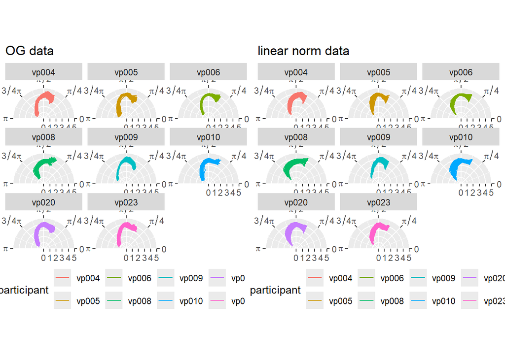

```r
grid.arrange(polar_plot_z_per_part, polar_plot_linear_norm, ncol = 2)
```

The new splines look different but overall keep their general shape. The one’s with a upward-pointing tongue tip (e.g. participant 8) might look a bit weird. We have to keep that in mind when interpreting the following results.

We will now calculate a new GAM:

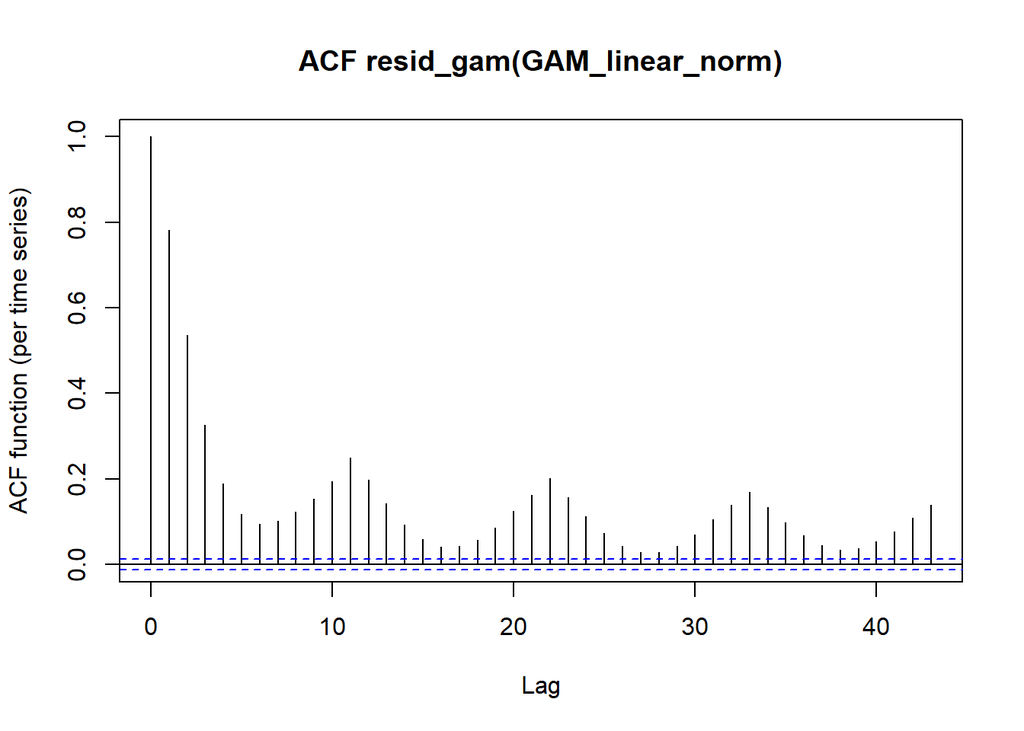

```r
GAM_linear_norm <- bam(radius ~ participant + s(angle, by = factor(participant)),
            discrete = TRUE,
            family = 'scat',
            data = linear_norm_static_polar_curves
)
AR1.rho <- acf_resid(GAM_linear_norm)[2]
```

Taking autocorrelation into account:

```r
GAM_linear_norm <- bam(radius ~ participant + s(angle, by = factor(participant)),
                          discrete = TRUE,
                        family = 'scat',
                        rho = AR1.rho,
                        AR.start = linear_norm_static_polar_curves %>% pull(knot) == 0,
                        data = linear_norm_static_polar_curves
)
summary(GAM_linear_norm)
```

```
##
## Family: Scaled t(3.849,0.135)
## Link function: identity
##
## Formula:
## radius ~ participant + s(angle, by = factor(participant))
##
## Parametric coefficients:
##                   Estimate Std. Error t value Pr(>|t|)
## (Intercept)       2.884573   0.009061 318.335  < 2e-16 ***
## participantvp005  0.069176   0.011068   6.250 4.17e-10 ***
## participantvp006  0.206704   0.011050  18.706  < 2e-16 ***
## participantvp008  0.291163   0.011167  26.073  < 2e-16 ***
## participantvp009 -0.032039   0.012773  -2.508   0.0121 *
## participantvp010  0.074754   0.011050   6.765 1.37e-11 ***
## participantvp020  0.176598   0.011027  16.014  < 2e-16 ***
## participantvp023  0.023698   0.011039   2.147   0.0318 *
## ---
## Signif. codes:  0 '***' 0.001 '**' 0.01 '*' 0.05 '.' 0.1 ' ' 1
##
## Approximate significance of smooth terms:
##                                     edf Ref.df    F p-value
## s(angle):factor(participant)vp004 8.902  8.998 2887  <2e-16 ***
## s(angle):factor(participant)vp005 8.972  9.000 7481  <2e-16 ***
## s(angle):factor(participant)vp006 8.939  8.999 7914  <2e-16 ***
## s(angle):factor(participant)vp008 8.977  9.000 7722  <2e-16 ***
## s(angle):factor(participant)vp009 8.949  8.999 2919  <2e-16 ***
## s(angle):factor(participant)vp010 8.943  8.999 6711  <2e-16 ***
## s(angle):factor(participant)vp020 8.945  8.999 7774  <2e-16 ***
## s(angle):factor(participant)vp023 8.972  9.000 6553  <2e-16 ***
## ---
## Signif. codes:  0 '***' 0.001 '**' 0.01 '*' 0.05 '.' 0.1 ' ' 1
##
## R-sq.(adj) =  0.959   Deviance explained = 83.4%
## fREML =  28819  Scale est. = 1         n = 23782
```

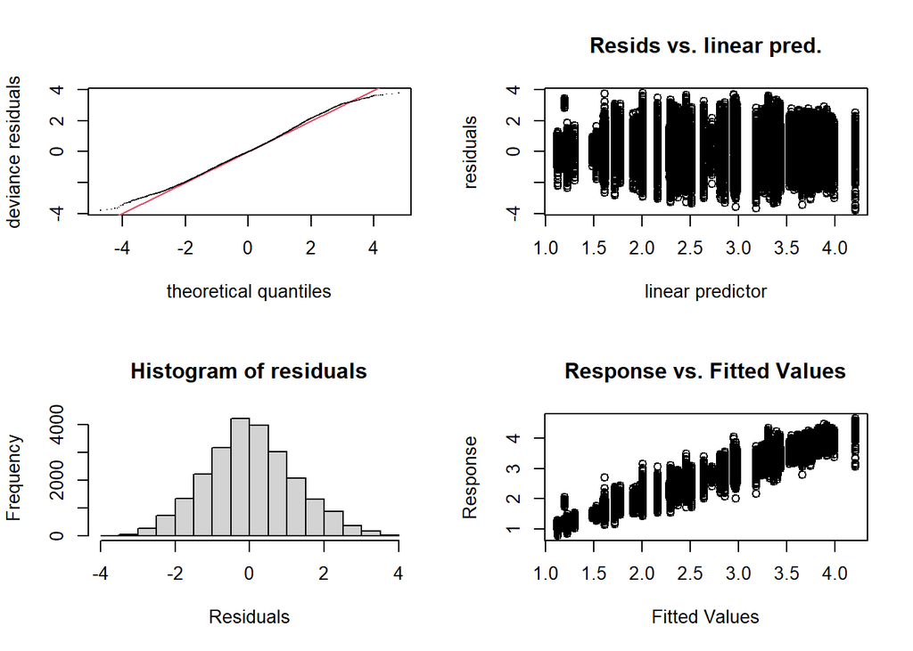

```
##
## Method: fREML   Optimizer: perf chol
## $grad
## [1] 4.699575e-09 3.959943e-12 6.376671e-09 1.003952e-10 1.012669e-09
## [6] 4.153379e-09 6.439294e-14 5.506706e-14
##
## $hess
##               [,1]          [,2]          [,3]          [,4]          [,5]
## [1,]  3.977917e+00 -7.004902e-21  4.830483e-20  1.941218e-20  2.492490e-20
## [2,]  4.717861e-20  3.987036e+00 -1.203846e-35  1.203700e-34  4.212917e-35
## [3,] -3.766731e-20  9.629510e-35  3.982832e+00  1.588883e-33  4.250290e-35
## [4,]  3.500377e-20  1.564812e-34  1.348142e-33  3.978567e+00 -1.203712e-34
## [5,]  2.595397e-20  1.955968e-35  2.294267e-35 -1.685194e-34  3.990773e+00
## [6,]  6.018510e-34 -3.318575e-39 -3.851891e-34  1.444437e-34  4.814757e-35
## [7,] -3.333546e-20 -1.414390e-34 -5.296469e-34  1.444418e-34  1.805324e-35
## [8,]  1.046435e-21  8.425836e-35 -2.364686e-39  3.550897e-34 -2.858915e-35
##               [,6]          [,7]          [,8]
## [1,] -1.355518e-20 -3.868496e-20 -3.745096e-20
## [2,] -8.426275e-35 -9.028151e-35 -4.213079e-35
## [3,] -1.444478e-34 -3.370539e-34  2.166648e-34
## [4,] -2.888905e-34 -9.629947e-35  1.384226e-34
## [5,] -1.805628e-35  3.009030e-35 -9.028926e-36
## [6,]  3.969138e+00  6.017558e-35 -1.324143e-34
## [7,]  1.986018e-34  3.988265e+00 -1.203912e-35
## [8,] -1.730394e-34 -3.611324e-35  3.982519e+00
##
## Model rank =  80 / 80
##
## Basis dimension (k) checking results. Low p-value (k-index<1) may
## indicate that k is too low, especially if edf is close to k'.
##
##                                     k'  edf k-index p-value
## s(angle):factor(participant)vp004 9.00 8.90       1    0.40
## s(angle):factor(participant)vp005 9.00 8.97       1    0.41
## s(angle):factor(participant)vp006 9.00 8.94       1    0.42
## s(angle):factor(participant)vp008 9.00 8.98       1    0.38
## s(angle):factor(participant)vp009 9.00 8.95       1    0.38
## s(angle):factor(participant)vp010 9.00 8.94       1    0.41
## s(angle):factor(participant)vp020 9.00 8.94       1    0.38
## s(angle):factor(participant)vp023 9.00 8.97       1    0.43
```

```r
gam.check(GAM_linear_norm)
```

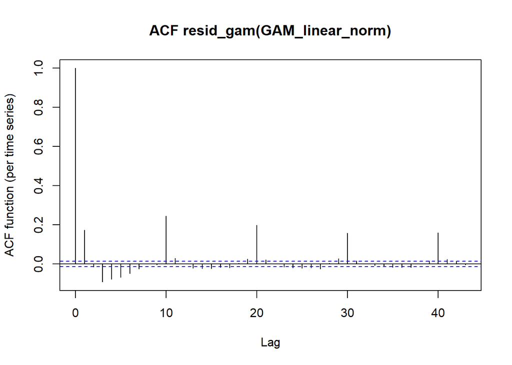

```r
acf_resid(GAM_linear_norm)
```

Get the predictions and plot:

```r
angle_grid_plot <- angle_grid
pred <- get_predictions(GAM_linear_norm,
                        cond = list(angle = angle_grid_plot,
                                    participant = factor(rhotic_data_static_polar$participant) %>% levels()),
                        print.summary = FALSE)

gam_polar_lin_plot <- ggplot(pred) +
  aes(x = angle, y = fit, group = participant) +
  geom_line(mapping = aes(color = participant)) +
  geom_ribbon(mapping = aes(ymin = fit - CI, ymax = fit + CI, fill = participant), alpha = 0.5) +
  radial_plot(5) +
  theme(legend.position = "bottom")
```

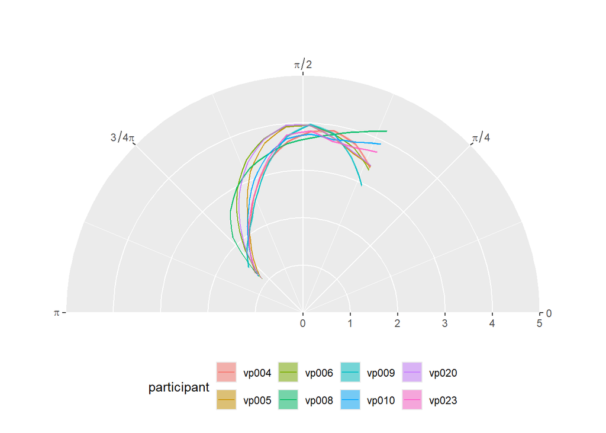

```r
gam_polar_lin_plot
```

The most important thing first: the tongue root looks definitely better than in the plot before.

The tongue tips of participants 8, 10 and 23 are clearly raised in this prediction plot. In the prediction plot of the first polar GAM, the tongue tip of participant 23 looked a bit different and more pointed downwards. Another aspect is the part between tongue dorsum and tongue root. In the new prediction plot, the participants are very different from each other in this part – e.g. participant 8’s spline is more bulbous and goes further back than the spline of the other participants in that region, the contour of participant 5 is very steep, etc. In the first prediction plot, all of the participants had a very similar tongue shape in that region. It’s very hard to tell which of those plots represents the real data “better”. The participants do show differences in the tongue root-tongue dorsum region, but it seems a bit over-exaggerated in the new plot using the linear normalized data, e.g., participant 8’s splines do seem bulbous in that part but it does not seem to be so far back in comparison with the other participants.

One thing that’s odd are the very small confidence interval ribbons in the new plot. The original data definitely shows a big spread for nearly all of the participants in the tongue tip area, especially for participants 5 and 6. While the old plot showed a wider ribbon in this region, that’s not the case for the new plot where the confidence interval is similarly small at the tongue tip as in any other region.

##### Procrustean angle range

We will now try an additional way of normalizing the data – the procrustean fit. This is typically used to analyse shapes. In this case we use it to make all of the tongue splines comparable to the median tongue spline that we calculated above (median of knot 0, median of knot 10 and then interpolate for the “knots” inbetween) and saved in the `angle_grid`.

```r
proc_static_polar_curves <- rhotic_data_static_polar %>%
  group_by(participant, frame_id) %>%
  # interpolation using the angle_grid
  reframe(bind_cols(
    knot = seq(along.with = angle_grid, from = 0), # fake knots, needed for AR1 term in GAM
    approx(angle, radius, angle_grid, rule = 2) %>% as_tibble()
    )) %>%
  rename(angle = x, radius = y)
```

Comparison of the original data set and the procrustean fit data set:

```r
polar_plot_proc <- ggplot(proc_static_polar_curves) +
    aes(angle, radius, group = frame_id, color = participant) +
    geom_path() +
    ggtitle("procrustean fit data") +
    radial_plot(5) +
    theme(legend.position = "bottom") + facet_wrap(vars(participant), ncol = 3)
```

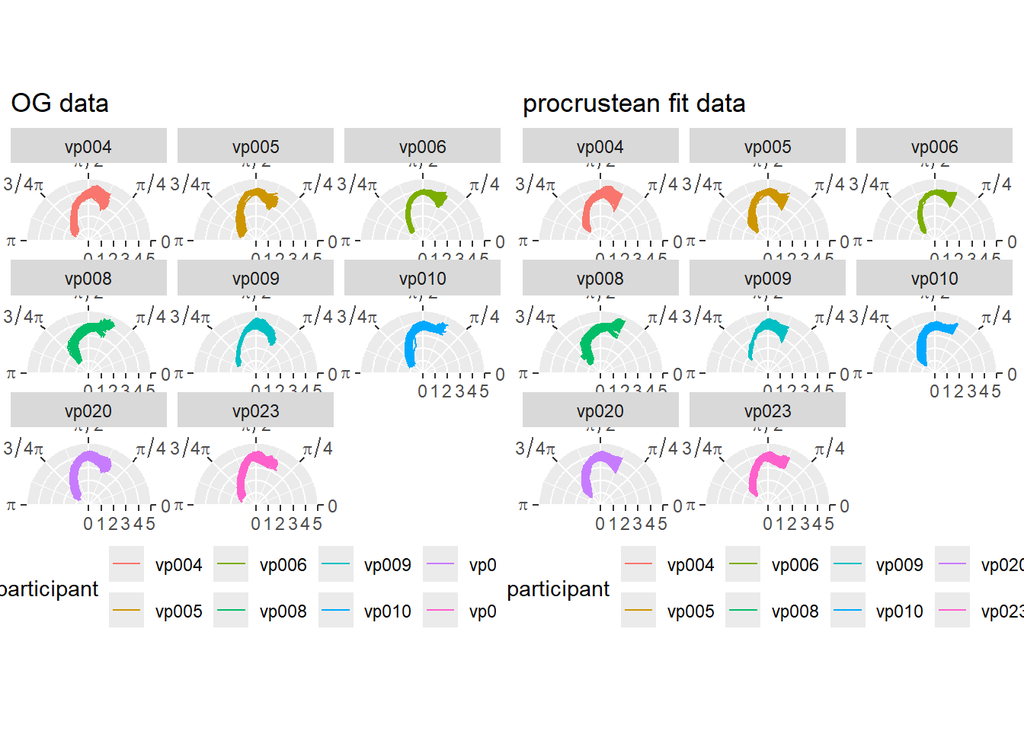

```r
grid.arrange(polar_plot_z_per_part, polar_plot_proc, ncol = 2)
```

In comparison to the linear normalized, the procrustean fit data looks a bit more similar to the original data. Especially the splines of participant 8 (linear normalized: their splines looked very flat, the upwards pointed tongue tip nearly got lost) and participant 10 (linear normalized: back part of the tongue splines looked bulbous and like there was a huge spread between the tongue splines that can’t be found in the original data).

The only thing that looks really weird is that at the tongue root, some splines of participant 8 look weird in the sense that they’re not going more or less straight downwards but instead “jump around”:

```r
polar_plot_proc_ex_8 <- ggplot(proc_static_polar_curves %>% filter(participant == "vp008" & frame_id %in% c("1031", "1044", "944", "896"))) +
    aes(angle, radius, group = frame_id, color = participant) +
    geom_path() +
    ggtitle("examples of weird tongue roots of participant 8\nprocrustean fit data") +
    radial_plot(5) +
    theme(legend.position = "bottom") + facet_wrap(vars(frame_id), ncol = 2)
```

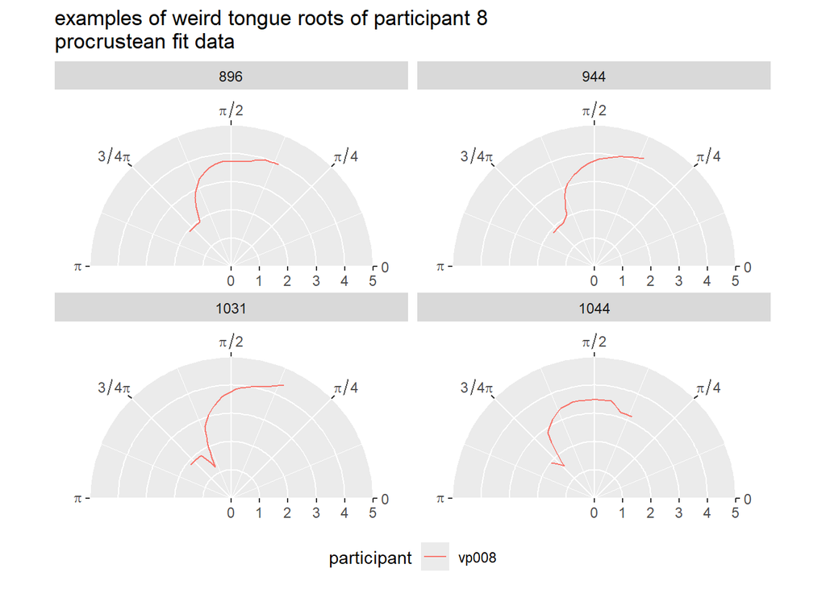

```r
polar_plot_proc_ex_8
```

Let’s keep this in mind when interpreting the results later.

Then calculate the new GAM:

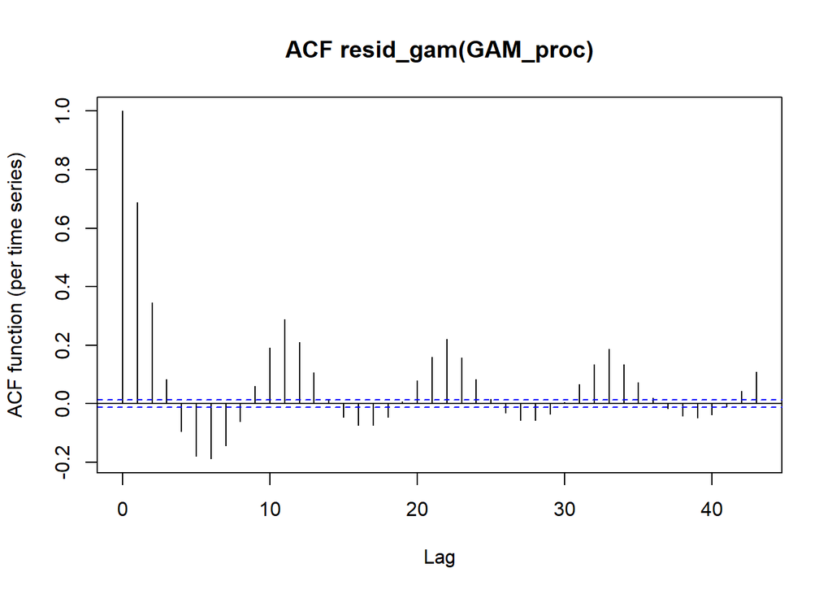

```r
GAM_proc <- bam(radius ~ participant + s(angle, by = factor(participant)),
            discrete = TRUE,
            family = 'scat',
            data = proc_static_polar_curves
)
AR1.rho <- acf_resid(GAM_proc)[2]
```

Taking autocorrelation into account:

```r
GAM_proc <- bam(radius ~ participant + s(angle, by = factor(participant)),
                          discrete = TRUE,
                        family = 'scat',
                        rho = AR1.rho,
                        AR.start = proc_static_polar_curves %>% pull(knot) == 0,
                        data = proc_static_polar_curves
)
summary(GAM_proc)
```

```
##
## Family: Scaled t(3.526,0.12)
## Link function: identity
##
## Formula:
## radius ~ participant + s(angle, by = factor(participant))
##
## Parametric coefficients:
##                   Estimate Std. Error t value Pr(>|t|)
## (Intercept)       3.034715   0.007157 424.003  < 2e-16 ***
## participantvp005 -0.011600   0.008742  -1.327   0.1846
## participantvp006 -0.074040   0.008728  -8.483  < 2e-16 ***
## participantvp008 -0.101171   0.008821 -11.470  < 2e-16 ***
## participantvp009  0.047221   0.010089   4.680 2.88e-06 ***
## participantvp010 -0.043089   0.008728  -4.937 8.00e-07 ***
## participantvp020 -0.017893   0.008710  -2.054   0.0400 *
## participantvp023  0.027370   0.008719   3.139   0.0017 **
## ---
## Signif. codes:  0 '***' 0.001 '**' 0.01 '*' 0.05 '.' 0.1 ' ' 1
##
## Approximate significance of smooth terms:
##                                     edf Ref.df    F p-value
## s(angle):factor(participant)vp004 8.839  8.994 2681  <2e-16 ***
## s(angle):factor(participant)vp005 8.958  9.000 7667  <2e-16 ***
## s(angle):factor(participant)vp006 8.982  9.000 9132  <2e-16 ***
## s(angle):factor(participant)vp008 8.986  9.000 9049  <2e-16 ***
## s(angle):factor(participant)vp009 8.905  8.998 2432  <2e-16 ***
## s(angle):factor(participant)vp010 8.945  8.999 7477  <2e-16 ***
## s(angle):factor(participant)vp020 8.962  9.000 8502  <2e-16 ***
## s(angle):factor(participant)vp023 8.960  9.000 6023  <2e-16 ***
## ---
## Signif. codes:  0 '***' 0.001 '**' 0.01 '*' 0.05 '.' 0.1 ' ' 1
##
## R-sq.(adj) =  0.965   Deviance explained = 83.6%
## fREML =  32575  Scale est. = 1         n = 23782
```

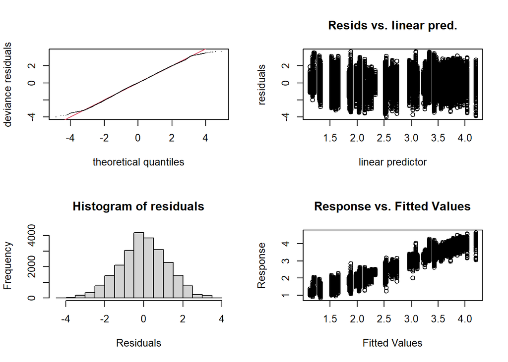

```
##
## Method: fREML   Optimizer: perf chol
## $grad
## [1]  4.092282e-12  4.325429e-13  4.378542e-11  1.854827e-11  3.374190e-12
## [6] -1.346034e-12  7.097922e-11  7.993606e-14
##
## $hess
##               [,1]          [,2]          [,3]          [,4]          [,5]
## [1,]  3.949787e+00  5.350079e-21  4.881912e-20  1.882907e-21  1.843762e-20
## [2,] -4.939215e-21  3.985055e+00 -4.445448e-35  2.004574e-50  5.159607e-35
## [3,] -1.449912e-20 -4.573920e-35  3.980448e+00  1.439156e-37 -4.573920e-35
## [4,] -1.730365e-35  1.353098e-36 -2.706197e-36  3.985151e+00  1.353098e-36
## [5,]  5.038920e-20  5.366054e-35 -1.073211e-34  3.023565e-50  3.975998e+00
## [6,]  5.849352e-21  1.255946e-35 -9.120412e-35 -1.597257e-37  1.834523e-35
## [7,] -2.888911e-34 -9.500622e-35  2.065760e-34 -1.125497e-36 -5.551541e-35
## [8,] -4.814829e-34 -4.718921e-35  1.349407e-34 -2.555831e-50 -4.718921e-35
##               [,6]          [,7]          [,8]
## [1,]  2.552833e-20 -1.204953e-19  4.680135e-20
## [2,] -5.569737e-36 -4.207126e-35 -8.851107e-35
## [3,]  3.046952e-49 -8.218081e-35  5.715312e-35
## [4,]  2.551602e-35 -2.084756e-49 -7.589256e-35
## [5,] -1.069106e-50  4.147670e-35 -1.182211e-34
## [6,]  3.955631e+00 -8.134142e-35 -1.022498e-34
## [7,] -5.345529e-50  3.975131e+00  1.731812e-34
## [8,]  9.463845e-36 -4.692728e-35  3.965375e+00
##
## Model rank =  80 / 80
##
## Basis dimension (k) checking results. Low p-value (k-index<1) may
## indicate that k is too low, especially if edf is close to k'.
##
##                                     k'  edf k-index p-value
## s(angle):factor(participant)vp004 9.00 8.84    0.98   0.080 .
## s(angle):factor(participant)vp005 9.00 8.96    0.98   0.070 .
## s(angle):factor(participant)vp006 9.00 8.98    0.98   0.090 .
## s(angle):factor(participant)vp008 9.00 8.99    0.98   0.100 .
## s(angle):factor(participant)vp009 9.00 8.90    0.98   0.090 .
## s(angle):factor(participant)vp010 9.00 8.95    0.98   0.065 .
## s(angle):factor(participant)vp020 9.00 8.96    0.98   0.110
## s(angle):factor(participant)vp023 9.00 8.96    0.98   0.065 .
## ---
## Signif. codes:  0 '***' 0.001 '**' 0.01 '*' 0.05 '.' 0.1 ' ' 1
```

```r
gam.check(GAM_proc)
```

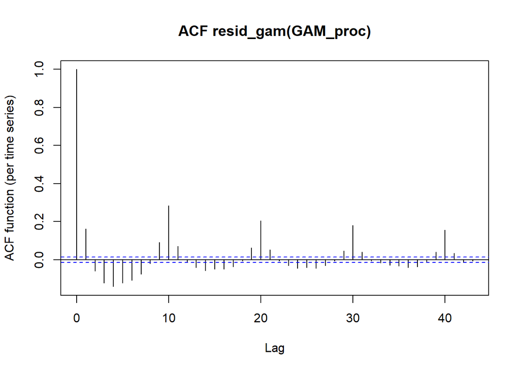

```r
acf_resid(GAM_proc)
```

Get the predictions and plot:

```r
pred <- get_predictions(GAM_proc,
                        cond = list(angle = angle_grid_plot,
                                    participant = factor(rhotic_data_static_polar$participant) %>% levels()),
                        print.summary = FALSE)

gam_polar_proc_plot <- ggplot(pred) +
  aes(x = angle, y = fit, group = participant) +
  geom_line(mapping = aes(color = participant)) +
  geom_ribbon(mapping = aes(ymin = fit - CI, ymax = fit + CI, fill = participant), alpha = 0.5) +
  radial_plot(5) +
  theme(legend.position = "bottom")
```

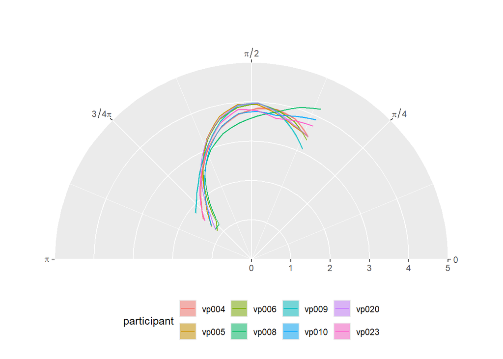

```r
gam_polar_proc_plot
```

The tongue dorsum and tongue root look more similar in this plot to the one in the beginning than to the one using the linear normalization. Nonetheless, it does not have the weird values around the tongue root that we had in the first GAM, which is good. As in the first GAM, the values between tongue root and tongue dorsum are very close together. For the tongue dorsum, we see differences between the participants – participant 8 again has a flat spline while most of the others show a more raised tongue dorsum. The front part (tongue tip) looks very similar to the linear normalization.

#### cartesian coordinates

We have the option to use

1. univariate GAMs - GAMs with only one dependent variable (Gubian 2025)
2. multivariate GAMs - GAMs with more than one dependent variable (Coretta and Sakr 2025)

The outcome variables that we try to investigate for the cartesian UTI data are the x and y coordinates of the tongue splines. Per definition, these are *two* variables that we try to predict. So it would make sense to use a multivariate GAM. Nonetheless, it is also possible to use an univariate GAM for the data. The good thing about that is that it is a bit less complex. But it also ignores the correlation of x and y which is not that good. We will try univariate as well as multivariate GAMs for our data.

##### Univariate trick from Michele Gubian

We will encode the dimension as a factor with two levels (x & y). The dimension will be seen as a predictor variable. Since the `participant` variable is a predictor variable as well, we will create a compound factor out of these two to have only one predictor. The response variable will be the tongue position.

```r
# create compound factor participant.dim for all combinations of participant and dimension
rhotic_data_static_long <- rhotic_data_static %>%
             pivot_longer(c(x_mean_z, y_mean_z), names_to = 'dimension', values_to = 'position') %>%
             unite("participant.dim", c(participant, dimension), sep = ".") %>%
             mutate(participant.dim = factor(participant.dim)) %>%
             # order to capture AR along knots
             arrange(frame_id, participant.dim, knot)

# calculate GAM
GAM <- bam(position ~ participant.dim + s(knot, by = participant.dim),
           data = rhotic_data_static_long,
           family = 'scat',
           discrete = TRUE)

# autocorellation:
AR1.rho <- acf_resid(GAM)[2]
```

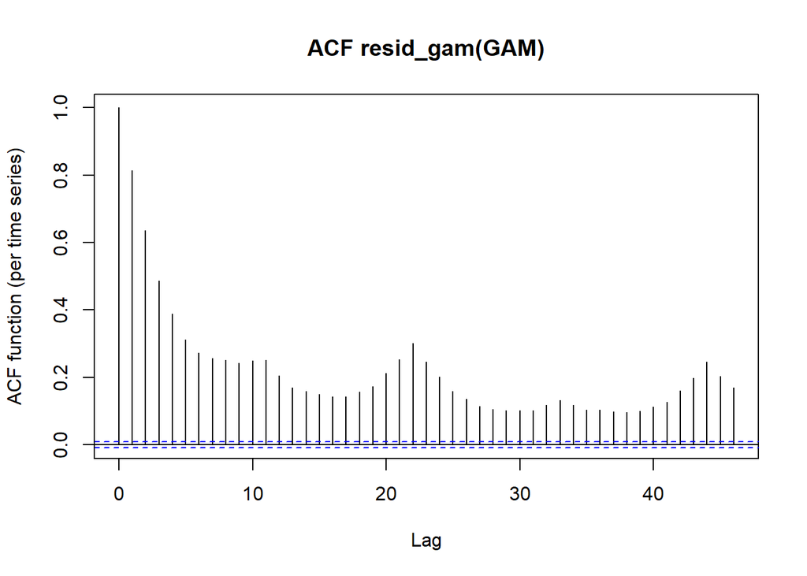

Model that takes into account the autocorrelation in the residuals:

```r
GAM <- bam(position ~ participant.dim + s(knot, by = participant.dim),
           data = rhotic_data_static_long,
           rho = AR1.rho, # error model for residuals
            AR.start = rhotic_data_static_long %>% pull(knot) == 0,
           family = 'scat',
           discrete = TRUE)
summary(GAM)
```

```
##
## Family: Scaled t(5.944,0.105)
## Link function: identity
##
## Formula:
## position ~ participant.dim + s(knot, by = participant.dim)
##
## Parametric coefficients:
##                                 Estimate Std. Error t value Pr(>|t|)
## (Intercept)                   -0.0019771  0.0070459  -0.281 0.779016
## participant.dimvp004.y_mean_z -0.0259143  0.0099645  -2.601 0.009307 **
## participant.dimvp005.x_mean_z  0.0069085  0.0086062   0.803 0.422134
## participant.dimvp005.y_mean_z -0.0157801  0.0086062  -1.834 0.066723 .
## participant.dimvp006.x_mean_z -0.0053414  0.0085925  -0.622 0.534189
## participant.dimvp006.y_mean_z -0.0294897  0.0085925  -3.432 0.000600 ***
## participant.dimvp008.x_mean_z  0.0073414  0.0086833   0.845 0.397861
## participant.dimvp008.y_mean_z -0.0076480  0.0086833  -0.881 0.378446
## participant.dimvp009.x_mean_z -0.0002201  0.0099320  -0.022 0.982317
## participant.dimvp009.y_mean_z -0.0334288  0.0099321  -3.366 0.000764 ***
## participant.dimvp010.x_mean_z -0.0045040  0.0085925  -0.524 0.600159
## participant.dimvp010.y_mean_z -0.0168997  0.0085925  -1.967 0.049214 *
## participant.dimvp020.x_mean_z  0.0036436  0.0085747   0.425 0.670891
## participant.dimvp020.y_mean_z -0.0158450  0.0085747  -1.848 0.064626 .
## participant.dimvp023.x_mean_z -0.0052482  0.0085836  -0.611 0.540921
## participant.dimvp023.y_mean_z -0.0123695  0.0085836  -1.441 0.149571
## ---
## Signif. codes:  0 '***' 0.001 '**' 0.01 '*' 0.05 '.' 0.1 ' ' 1
##
## Approximate significance of smooth terms:
##                                         edf Ref.df     F p-value
## s(knot):participant.dimvp004.x_mean_z 8.957  9.000  6066  <2e-16 ***
## s(knot):participant.dimvp004.y_mean_z 8.967  9.000 10800  <2e-16 ***
## s(knot):participant.dimvp005.x_mean_z 8.986  9.000 13050  <2e-16 ***
## s(knot):participant.dimvp005.y_mean_z 8.990  9.000 23951  <2e-16 ***
## s(knot):participant.dimvp006.x_mean_z 8.989  9.000 12973  <2e-16 ***
## s(knot):participant.dimvp006.y_mean_z 8.988  9.000 21291  <2e-16 ***
## s(knot):participant.dimvp008.x_mean_z 8.985  9.000 12859  <2e-16 ***
## s(knot):participant.dimvp008.y_mean_z 8.962  9.000 15618  <2e-16 ***
## s(knot):participant.dimvp009.x_mean_z 8.945  8.999  6090  <2e-16 ***
## s(knot):participant.dimvp009.y_mean_z 8.981  9.000 13259  <2e-16 ***
## s(knot):participant.dimvp010.x_mean_z 8.984  9.000 12864  <2e-16 ***
## s(knot):participant.dimvp010.y_mean_z 8.988  9.000 19889  <2e-16 ***
## s(knot):participant.dimvp020.x_mean_z 8.989  9.000 13574  <2e-16 ***
## s(knot):participant.dimvp020.y_mean_z 8.991  9.000 22966  <2e-16 ***
## s(knot):participant.dimvp023.x_mean_z 8.986  9.000 12819  <2e-16 ***
## s(knot):participant.dimvp023.y_mean_z 8.993  9.000 23478  <2e-16 ***
## ---
## Signif. codes:  0 '***' 0.001 '**' 0.01 '*' 0.05 '.' 0.1 ' ' 1
##
## R-sq.(adj) =  0.983   Deviance explained = 91.1%
## fREML =  50916  Scale est. = 1         n = 47564
```

Check the GAM and the distribution of residuals:

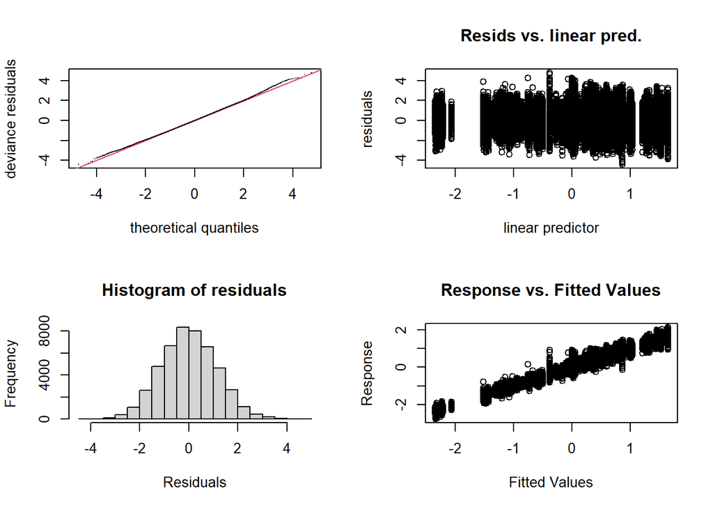

```
##
## Method: fREML   Optimizer: perf chol
## $grad
##  [1]  8.881784e-16  3.365752e-12 -1.332268e-15  1.243450e-14  9.814372e-14
##  [6]  4.605205e-13 -1.820766e-14 -7.993606e-15 -3.037570e-13  2.566836e-13
## [11] -6.217249e-15 -3.996803e-14 -1.909584e-14  1.687539e-14 -2.220446e-15
## [16]  4.440892e-16
##
## $hess
##                [,1]          [,2]          [,3]          [,4]          [,5]
##  [1,]  3.986783e+00 -1.312513e-20  2.810623e-21  2.213625e-21 -6.220231e-21
##  [2,]  2.708323e-35  3.993161e+00 -1.200922e-35  4.042524e-36 -1.200526e-35
##  [3,]  6.344612e-22 -2.145890e-36  3.995860e+00 -6.457209e-36  1.116223e-35
##  [4,] -4.020204e-21 -3.667843e-36 -3.189411e-36  3.997993e+00 -2.494933e-36
##  [5,] -7.568771e-21  8.820124e-50  4.997017e-36 -2.498509e-36  3.995903e+00
##  [6,] -1.715726e-21  4.061364e-36 -7.463161e-36  4.682847e-36 -1.333684e-35
##  [7,]  3.009260e-35 -5.345529e-50 -8.207667e-36  6.627704e-36 -9.112405e-36
##  [8,] -2.360374e-20 -3.314228e-49 -4.034055e-35  1.813549e-35 -3.627097e-35
##  [9,] -4.168893e-21  5.932616e-36 -1.314224e-35 -6.747936e-37  1.349587e-36
## [10,] -3.289315e-21  3.901694e-36 -4.137222e-36  2.596596e-37 -5.193191e-37
## [11,] -1.317528e-20 -2.504550e-36 -2.788006e-36  4.597271e-36 -9.287255e-36
## [12,] -6.853338e-21  5.640641e-36  3.739005e-36 -2.671897e-36  1.122693e-36
## [13,]  5.784175e-22  2.028203e-36  5.428476e-36 -1.078656e-36  5.258409e-36
## [14,]  6.018523e-35  4.108092e-36 -1.308079e-36  6.955188e-36 -1.104422e-35
## [15,]  4.849045e-21  5.329355e-36  6.403862e-37  1.141773e-38  2.852349e-36
## [16,]  3.009203e-36  1.737297e-50  1.987981e-36  1.737592e-37  3.655012e-36
##                [,6]          [,7]          [,8]          [,9]         [,10]
##  [1,] -1.215258e-20 -1.064996e-20  3.752836e-21  2.523301e-22 -6.385809e-22
##  [2,] -8.304518e-37  1.308887e-36  4.584761e-35 -1.119220e-49  2.505717e-50
##  [3,]  1.363110e-49  1.122561e-49 -4.991891e-35  2.265960e-38 -3.243187e-37
##  [4,] -1.637068e-50 -5.512577e-51  1.700171e-35 -3.398379e-50  7.684199e-51
##  [5,]  8.686485e-50  5.078253e-50 -3.586100e-35  5.376851e-50 -8.435914e-51
##  [6,]  3.996896e+00  3.477640e-36  3.746278e-35 -7.691589e-38  2.088097e-50
##  [7,] -6.414635e-50  3.994475e+00  3.283067e-35 -8.736600e-50  1.820821e-50
##  [8,] -2.779675e-49 -1.710569e-49  3.986156e+00 -3.598209e-49  6.949188e-50
##  [9,]  2.018423e-36 -9.779745e-36  1.455343e-37  3.974593e+00 -1.157503e-37
## [10,] -1.538145e-36 -4.140385e-37 -6.887511e-36 -5.603931e-51  3.996027e+00
## [11,]  8.728631e-36 -6.435659e-36  4.113902e-35 -9.238494e-38  2.472307e-50
## [12,]  2.423117e-37  3.678140e-36 -2.137517e-35 -9.048471e-38  2.026592e-37
## [13,] -6.272178e-37 -7.542794e-36  2.194235e-37 -9.521808e-38 -4.760862e-51
```

[output cut: 45 more lines]

```
## s(knot):participant.dimvp004.y_mean_z 9.00 8.97    1.01    0.79
## s(knot):participant.dimvp005.x_mean_z 9.00 8.99    1.01    0.80
## s(knot):participant.dimvp005.y_mean_z 9.00 8.99    1.01    0.81
## s(knot):participant.dimvp006.x_mean_z 9.00 8.99    1.01    0.80
## s(knot):participant.dimvp006.y_mean_z 9.00 8.99    1.01    0.80
## s(knot):participant.dimvp008.x_mean_z 9.00 8.99    1.01    0.86
## s(knot):participant.dimvp008.y_mean_z 9.00 8.96    1.01    0.79
## s(knot):participant.dimvp009.x_mean_z 9.00 8.94    1.01    0.80
## s(knot):participant.dimvp009.y_mean_z 9.00 8.98    1.01    0.83
## s(knot):participant.dimvp010.x_mean_z 9.00 8.98    1.01    0.81
## s(knot):participant.dimvp010.y_mean_z 9.00 8.99    1.01    0.85
## s(knot):participant.dimvp020.x_mean_z 9.00 8.99    1.01    0.83
## s(knot):participant.dimvp020.y_mean_z 9.00 8.99    1.01    0.86
## s(knot):participant.dimvp023.x_mean_z 9.00 8.99    1.01    0.82
## s(knot):participant.dimvp023.y_mean_z 9.00 8.99    1.01    0.86
```

```r
gam.check(GAM)
```

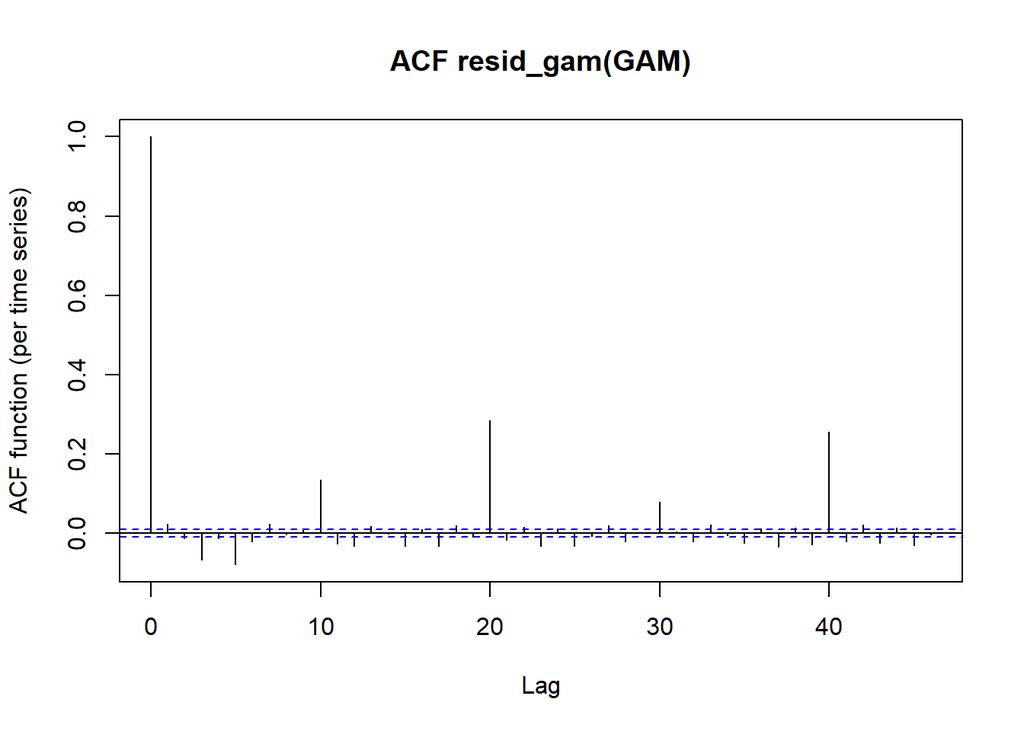

```r
acf_resid(GAM)
```

```r
gam_pred <- get_predictions(GAM,
                        cond = list(knot = 0:10,
                                    participant.dim = rhotic_data_static_long$participant.dim %>% levels()),
                        se = FALSE,
                        print.summary = FALSE) %>%
  separate_wider_delim(participant.dim, ".", names = c("participant", "dimension")) %>%
  pivot_wider(names_from = dimension, values_from = "fit")

gam_pred_plot <- ggplot(gam_pred) +
  aes(x_mean_z, y_mean_z, group = participant, color = participant) +
  geom_path() +
  geom_point(aes(color= participant)) +
  geom_text(aes(label = knot), check_overlap = TRUE,
            nudge_x = .05, nudge_y = .05, show.legend = FALSE) +
  theme(legend.position = "bottom")
```

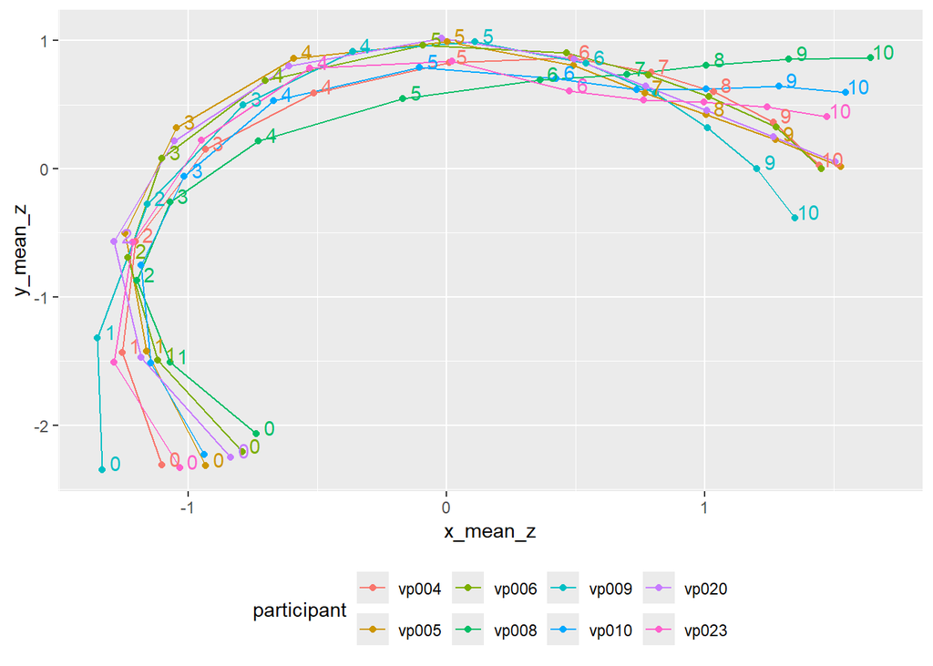

```r
gam_pred_plot
```

We can observe the same general tendencies as in the polar GAM prediction. Participant 8 shows the most raised tongue tip, participant 9 the most bunched tongue tip, the other participants are between those two. Participants 5, 6, 9 and 20 have a similarly high tongue dorsum, while the other participants’ tongue dorsums are slightly flatter (esp. participant 8’s tongue dorsum is clearly flatter). Between tongue dorsum and tongue root (knot 2 and 3), the participants are close together – at the tongue root (knot 0 and 1), the participants are spreading further apart. This was also the case in the procrustean normalized polar GAM – but not for the linear normalization. There, the GAM rather showed a wide spread at the transition from tongue dorsum to tongue root while the tongue roots of the participants were closer together.

We could now calculate difference plots between all of the participants. To calculate all of them would be a lot because we have 8 participants what would lead to 56 plots. So I will just do one to see what it looks like. The biggest difference seems to be between participant 8 and participant 9, so we will plot the difference plot of those two on both dimensions (x and y).

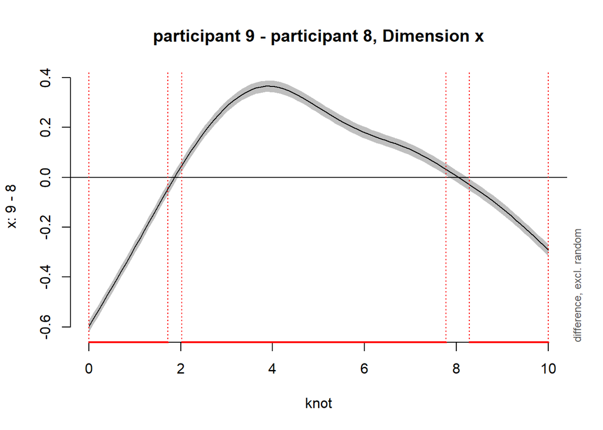

```r
plot_diff(GAM, view = "knot", comp = list(participant.dim = c("vp009.x_mean_z", "vp008.x_mean_z")),
            print.summary = FALSE, main = "participant 9 - participant 8, Dimension x", ylab = "x: 9 - 8")
```

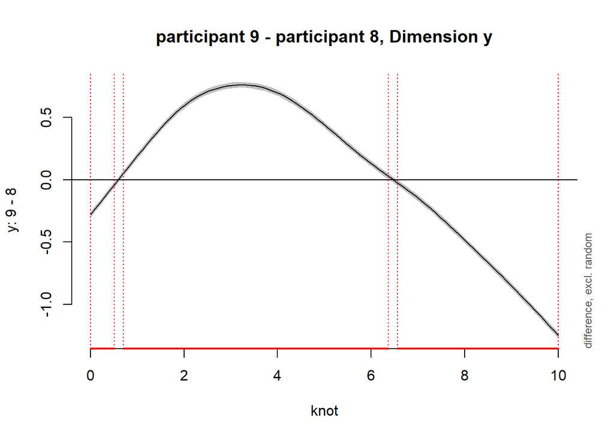

```r
plot_diff(GAM, view = "knot", comp = list(participant.dim = c("vp009.y_mean_z", "vp008.y_mean_z")),
            print.summary = FALSE, main = "participant 9 - participant 8, Dimension y", ylab = "y: 9 - 8")
```

The important thing to note here is that these difference plots only compare the differences at the specific knots. E.g. it tells us that knot 3 of participant 8 and participant 9 is significantly different in both dimensions. It would not tell us if instead of knot 2 of both participants, e.g. knot 3 of participant 8 and knot 2 of participant 9 are very close to each other. This is indeed the case as can be seen in the following plot:

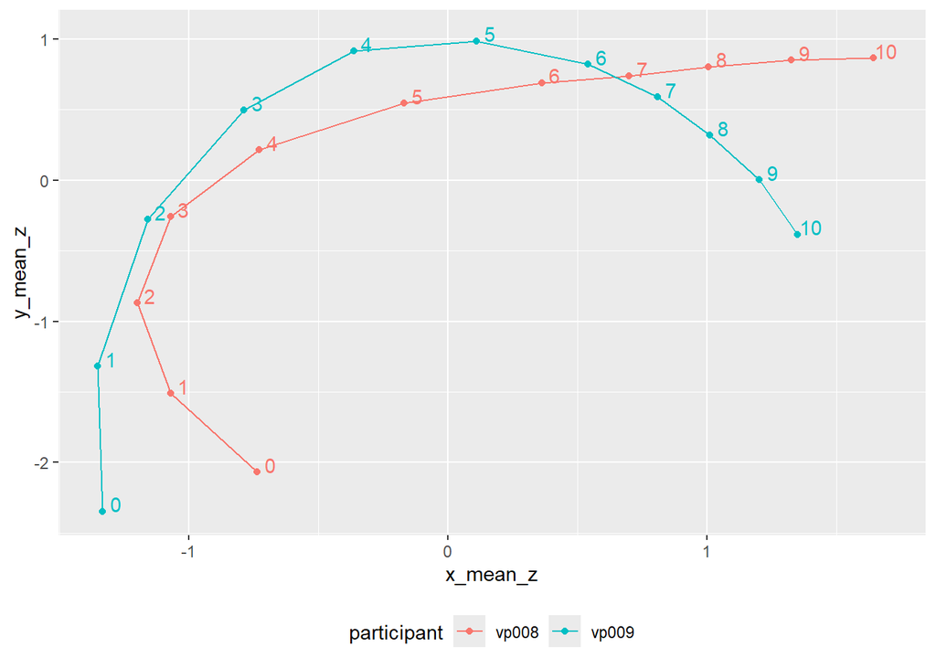

```r
gam_pred %>% filter(participant %in% c("vp008", "vp009")) %>%
ggplot() +
  aes(x_mean_z, y_mean_z, group = participant, color = participant) +
  geom_path() +
  geom_point(aes(color= participant)) +
  geom_text(aes(label = knot), check_overlap = TRUE,
            nudge_x = .05, nudge_y = .05, show.legend = FALSE) +
  theme(legend.position = "bottom")
```

##### Multivariate GAM from Stefano Coretta’s mv_uti

Instead of using the univariate GAM function, we will now follow the mv_uti tutorial by Stefano Coretta and calculate a multivariate (or – in this case – a bivariate) GAM. In this case the x and y variables will be modeled as “two variables changing along knot number” (Coretta and Sakr 2025).

This MGAM consists of:

- a list in which we define two model formulas - one for x, one for y
- `mvn(d = 2)` a multivariate normal family with two dimensions (x and y)
- a smooth over knot for both dependent variables s(knot, …) with a `by` variable that is in this case `participant`
- a `k` that is set to 5, because “X/Y coordinates of tongue contours […] are by nature not very “wiggly”” (Coretta and Sakr 2025).

A factor smooth over participant, as shown in Coretta (2025), would make no sense here because `participant` is our independet variable.

```r
mv_gam <- mgcv::gam(list(
    x_mean_z ~ factor(participant) +
      s(knot, by = factor(participant), k = 5),
    y_mean_z ~ factor(participant) +
      s(knot, by = factor(participant), k = 5)
  ),
  data = rhotic_data_static,
  family = mvn(d = 2) # multivariate normal family, two dimensions
)
```

GAM summary:

```r
summary(mv_gam)
```

```
##
## Family: Multivariate normal
## Link function:
##
## Formula:
## x_mean_z ~ factor(participant) + s(knot, by = factor(participant),
##     k = 5)
## y_mean_z ~ factor(participant) + s(knot, by = factor(participant),
##     k = 5)
##
## Parametric coefficients:
##                              Estimate Std. Error z value Pr(>|z|)
## (Intercept)                -3.211e-16  2.864e-03       0        1
## factor(participant)vp005   -1.553e-16  3.498e-03       0        1
## factor(participant)vp006   -2.443e-16  3.493e-03       0        1
## factor(participant)vp008   -2.773e-16  3.530e-03       0        1
## factor(participant)vp009   -1.750e-17  4.037e-03       0        1
## factor(participant)vp010   -1.509e-16  3.493e-03       0        1
## factor(participant)vp020   -2.511e-16  3.486e-03       0        1
## factor(participant)vp023   -1.347e-16  3.489e-03       0        1
## (Intercept).1               6.233e-16  3.608e-03       0        1
## factor(participant)vp005.1 -1.361e-16  4.407e-03       0        1
## factor(participant)vp006.1 -3.488e-16  4.400e-03       0        1
## factor(participant)vp008.1 -4.738e-16  4.446e-03       0        1
## factor(participant)vp009.1  2.215e-16  5.086e-03       0        1
## factor(participant)vp010.1 -4.053e-16  4.400e-03       0        1
## factor(participant)vp020.1 -2.447e-16  4.391e-03       0        1
## factor(participant)vp023.1 -2.285e-16  4.395e-03       0        1
##
## Approximate significance of smooth terms:
##                                      edf Ref.df Chi.sq p-value
## s(knot):factor(participant)vp004   3.998      4 120374  <2e-16 ***
## s(knot):factor(participant)vp005   3.999      4 244333  <2e-16 ***
## s(knot):factor(participant)vp006   3.999      4 246845  <2e-16 ***
## s(knot):factor(participant)vp008   3.999      4 230092  <2e-16 ***
## s(knot):factor(participant)vp009   3.996      4 122509  <2e-16 ***
## s(knot):factor(participant)vp010   3.999      4 246620  <2e-16 ***
## s(knot):factor(participant)vp020   3.999      4 249590  <2e-16 ***
## s(knot):factor(participant)vp023   3.999      4 248744  <2e-16 ***
## s.1(knot):factor(participant)vp004 3.997      4  74210  <2e-16 ***
## s.1(knot):factor(participant)vp005 3.999      4 153156  <2e-16 ***
## s.1(knot):factor(participant)vp006 3.999      4 154726  <2e-16 ***
## s.1(knot):factor(participant)vp008 3.996      4 145755  <2e-16 ***
## s.1(knot):factor(participant)vp009 3.998      4  75212  <2e-16 ***
## s.1(knot):factor(participant)vp010 3.999      4 154350  <2e-16 ***
## s.1(knot):factor(participant)vp020 3.999      4 155983  <2e-16 ***
## s.1(knot):factor(participant)vp023 3.999      4 154944  <2e-16 ***
## ---
## Signif. codes:  0 '***' 0.001 '**' 0.01 '*' 0.05 '.' 0.1 ' ' 1
##
## Deviance explained = 98.1%
## -REML = -73686  Scale est. = 1         n = 23782
```

We now want to plot the predicted tongue contours (step by step).

We need a grid to base our predictions on:

```r
# Create a grid of values to predict for
frame_mv_gam <- expand_grid(
  # All the speakers
  participant = unique(rhotic_data_static$participant),
  # Knots from 0 to 10 by increments of 0.1
  # This gives us greater resolution along the tongue contour than just using 10 knots
  knot = seq(0, 10, by = 0.1)
)
```

Now we extract predictions with `predict()`:

```r
mv_gam_predict <- predict(mv_gam, frame_mv_gam, se.fit = TRUE) |>
  as.data.frame() |>
  as_tibble()

# Rename columns
colnames(mv_gam_predict) <- c("x_mean_z", "y_mean_z", "x_se", "y_se")

# combine both data frames
mv_gam_predict <- bind_cols(frame_mv_gam, mv_gam_predict) %>%
  mutate(
    x_lo = x_mean_z - (1.96 * x_se),
    x_hi = x_mean_z + (1.96 * x_se),
    y_lo = y_mean_z - (1.96 * y_se),
    y_hi = y_mean_z + (1.96 * y_se)
  )
```

Now we plot:

```r
mv_gam_prediction_plot <- mv_gam_predict %>%
  ggplot(aes(x_mean_z, y_mean_z, colour = participant)) +
  geom_point(size = 1, alpha = 0.75) +
  coord_fixed() +
  theme(legend.position = "bottom")
```

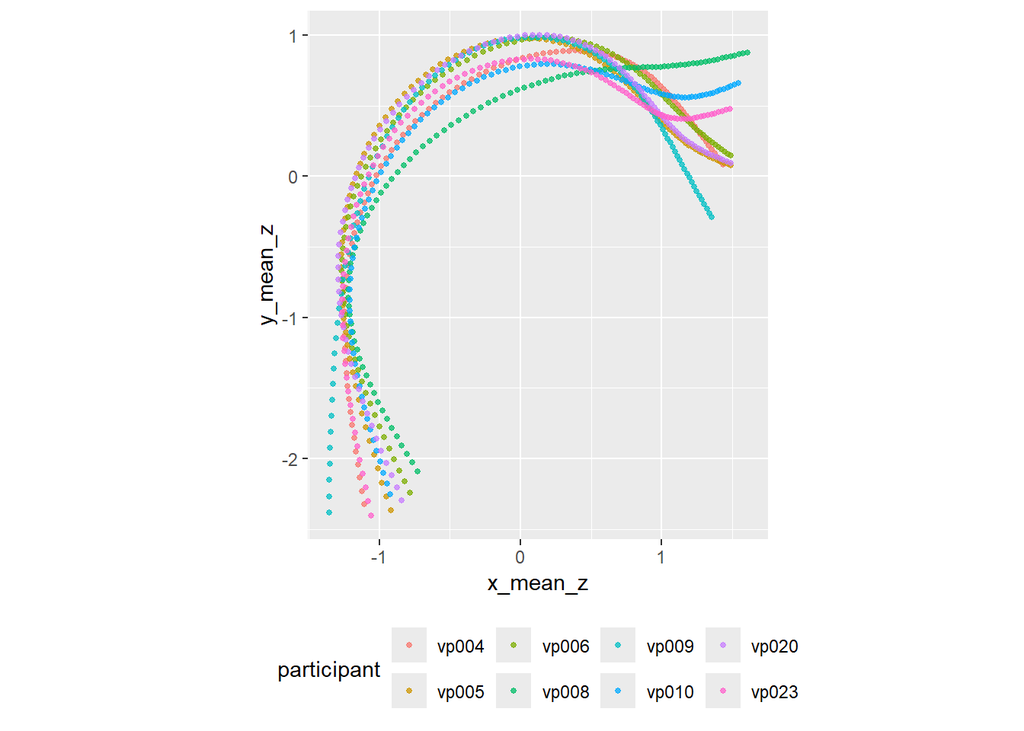

```r
mv_gam_prediction_plot
```

```r
mv_gam_prediction_plot2 <- mv_gam_predict %>%
  ggplot(aes(group = participant, color = participant)) +
  geom_path(aes(x = x_mean_z, y = y_mean_z)) +
  geom_path(aes(x = x_lo, y = y_lo), linetype = "dotted") +
  geom_path(aes(x = x_hi, y = y_hi), linetype = "dotted") +
  theme(legend.position = "bottom")
```

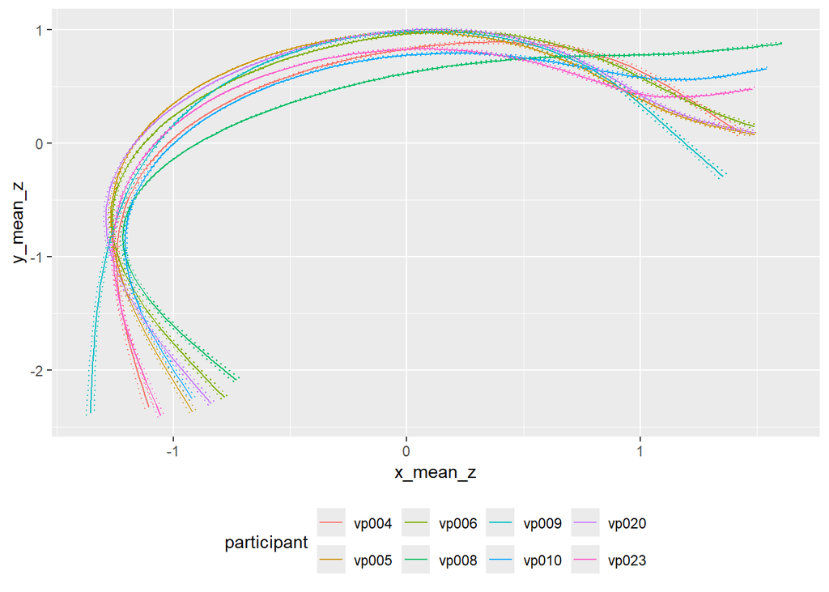

```r
mv_gam_prediction_plot2
```

### (M)FPCA

MFPCA is Multivariate Functional Principal Component Analysis. For a general tutorial see Gubian et al (2015).

#### polar coordinates

The FPCA calculation using the polar coordinates is based on Gubian (2025). We will first calculate an FPCA model. In that model we will be able to see the overall variation of our data. Then we will test if there’s a difference between the participants by calculating a linear model using the PC scores.

We will build a `funData` object to calculate a FPCA. For this, we will use the same data set that we used to calculate the GAMs – the one with the procrustean fit.

We use the `long2irregFunData` function from the `landmarkregUtils` package to convert our data to the correct data object. In the FPCA, the angle serves as a predictor variable for the dependent variable `radius`.

```r
# build a funData object
fpca_curves_static_polar_proc <- long2irregFunData(proc_static_polar_curves,
                                  id = "frame_id",
                                  time = "angle", # predictor variable
                                  value = "radius") %>% # dependent variable
  as.funData()
fpca_curves_static_polar_proc
```

```
## Functional data with 2162 observations of 1-dimensional support
## argvals:
##  1.136447 1.267896 ... 2.450935      (11 sampling points)
## X:
##  array of size 2162 x 11
```

```r
# Short interjection
# I tried to do this with the normal data, that is not normalized using the procrustean fit:

rhotic_static_polar_pca <- rhotic_data_static_polar %>% select(c("participant", "frame_id", "knot", "angle", "radius")) # same columns as "proc_static_polar_curves"

fpca_curves_static_polar <- long2irregFunData(rhotic_static_polar_pca,
                                  id = "frame_id",
                                  time = "angle",
                                  value = "radius") %>% as.funData()
fpca_curves_static_polar
```

```
## Functional data with 2162 observations of 1-dimensional support
## argvals:
##  0.9979241 1.007009 ... 2.939541     (23782 sampling points)
## X:
##  array of size 2162 x 23782
```

```r
# This says "Functional data with 2162 observations of 1-dimensional support [...] (23782 sampling points) [...] array of size 2162 x 23782"
# But that's not what we want, we want 11 sampling points and an array of size 2162 x 11. This is the exact same type of tibble as the "procrustean fit"-tibble. Why is this not working here? Can I make it work? I'd be interested in calculating the FPCA with the "original" polar data.
```

Then we can calculate the FPCA using the PACE function:

```r
# Compute FPCA
fpca_polar_static_proc <- PACE(fpca_curves_static_polar_proc)

# Prop of explained var
PropExpVar <- round(fpca_polar_static_proc$values  / sum(fpca_polar_static_proc$values), digits = 3)
```

```r
PropExpVar
```

```
## [1] 0.491 0.247 0.102 0.090 0.037 0.031
```

The `PACE` function automatically chooses how many Principle Components (PCs) to compute. Here, it computed 6 PCs. The 6 PCs cover 99 % of the variance in the data (Gubian 2025).

The first PC explains 49.1 % of the variance, the second PC 24.7 % of the variance and the third PC 10.2 %. We will now look at these three PCs.

```r
nPC <- 3
# scores st. dev.
sdFun <- fpca_polar_static_proc$values %>% sqrt()

# PC curves to be plotted
PCcurves_polar_static_proc <- expand_grid(PC = 1:nPC,
                        fractionOfStDev = seq(-1, 1, by=.25)) %>%
  group_by(PC, fractionOfStDev) %>%
  reframe(
    funData2long1(fpca_polar_static_proc$mu + fractionOfStDev * sdFun[PC] * fpca_polar_static_proc$functions[PC],
                  time = "angle", value = "radius")
  )
# Plot
FPCA_polar_static_proc_plot <- ggplot(PCcurves_polar_static_proc) +
  aes(x = angle, y = radius, group = fractionOfStDev, color = fractionOfStDev) +
  geom_line() +
  scale_color_gradient2(low = "blue", mid = "grey", high = "orangered",
                        breaks = c(-1, 0 , 1)) +
  facet_wrap(~ PC, ncol = 2,
             labeller = labeller(PC = ~ str_glue("PC{.x}"))) +
  labs(color = expression(frac(s[k], sigma[k]))) +
  geom_line(data = PCcurves_polar_static_proc %>% filter(fractionOfStDev == 0), color = 'black', linewidth = 1.2) +
  radial_plot(4) +
  theme(legend.position = "bottom")
```

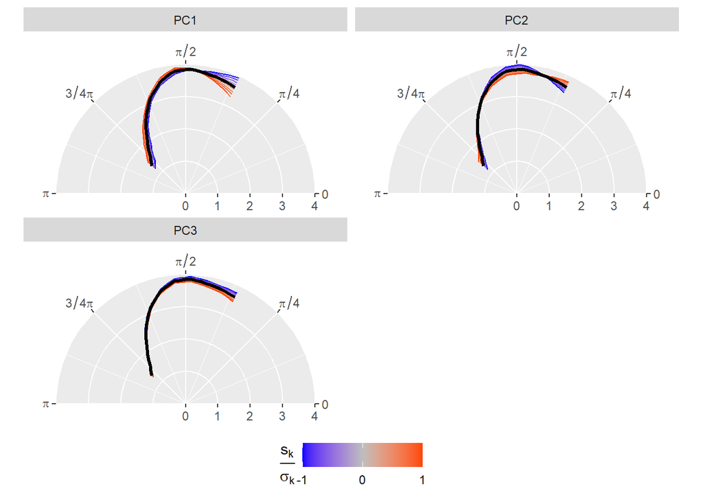

```r
FPCA_polar_static_proc_plot
```

The three PCs describe different shape variations in the data (independent of participant). Pictured in black is the predicted mean tongue contour. The coloured lines show the effect of the PCs – the lines in blue show a deviation from the mean up to -1 standard deviation, in orange up to +1 standard deviation of the respective PC. The different PCs are pictured independently – PC1 in the top left panel, PC2 in the top right panel, PC3 in the bottom.

The first PC score describes a variation of the tongue contour mainly in the front part of the tongue. A larger PC1 score (pictured in orange) describes a more downwards pointed tongue tip, a smaller PC1 score (pictured in blue) describes a more raised tongue tip. Additionally, the PC1 score describes a general retraction / fronting of the tongue: A larger PC1 score causes the whole contour to be slightly retracted, a smaller PC1 score causes the contour to be more fronted.

If we think about this in regards to the rhotics that we’re investigating, we could expect a smaller PC1 score describing alveolar/front rhotics (raised tongue tip, tongue moves forward) and a larger PC1 score describing uvular/back rhotics (bunched tongue, tongue tip is pointing downwards, tongue dorsum is raised).

PC2 mainly describes a tongue movement in the horizontal axis. A large PC2 score describes a general lowering of the tongue dorsum and a slight raising of the tongue tip, a smaller PC2 score describes a raising of the tongue dorsum and a slight lowering of the tongue tip. In general, a larger PC2 score describes a flat tongue contour, while a smaller PC2 score describes a steeper tongue with an arched tongue dorsum. This could translate to the rhotics as well – a smaller PC2 score could describe an uvular/back rhotic, a larger PC2 score could describe a more front/alveolar rhotic – although we would probably expect a more raised tongue tip. PC2 could also describe variation within the uvular rhotics: an uvular fricative would be expected to look like a tongue contour with a low PC2 score (very high tongue dorsum that probably causes a friction at the palate), an uvular approximant would probably look more like a tongue contour with a higher PC2.

PC3 also describes a horizontal variation: A low PC3 score describes a general raising of the whole tongue (tongue tip & tongue dorsum) – a high PC3 score describes a lowering of the whole tongue.

We will now plot the PC scores of the participants to see if they differ in their PC scores.

```r
# collect PC scores
PCscores_static_polar <- fpca_polar_static_proc$scores %>%
  `colnames<-`( paste0("s", 1:fpca_polar_static_proc$npc)) %>%
  as_tibble() %>%
  bind_cols(proc_static_polar_curves %>% distinct(frame_id, participant), .)

# boxplots PC scores by Category
FPCA_static_polar_boxplot <- PCscores_static_polar %>%
  pivot_longer(cols = s1:all_of(str_glue("s{fpca_polar_static_proc$npc}")),
               names_to = "PC", values_to = "score") %>%
  filter(PC %in% str_c("s", 1:nPC)) %>%
  ggplot() +
  aes(x = participant, y = score, color = participant) +
  geom_boxplot() +
  facet_wrap(~ PC) +
  theme(legend.position = "bottom")
```

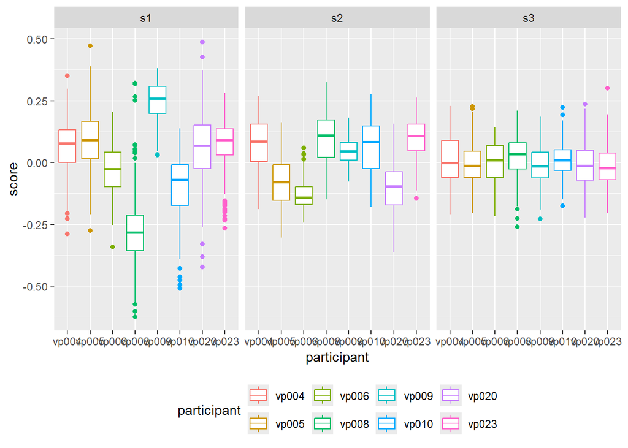

```r
FPCA_static_polar_boxplot
```

The boxplots show that the participants have a great variation in PC1 and PC2, but very similar PC3 scores. It seems like PC1 and PC2 are dependent on the variable `participant` while PC3 is independent. The variation pictured through the PC3 score could maybe be explained by another variable.

Another way to plot the PC1 and PC2 scores:

```r
# scatterplot PC scores s1 and s2 by participant
pc_mean <- PCscores_static_polar %>%
  group_by(participant) %>%
  summarise(
    mean_s1 = mean(s1),
    mean_s2 = mean(s2),
    mean_s3 = mean(s3)
  ) %>%
  ungroup()

PCscores_static_polar_scatterplot <- ggplot(PCscores_static_polar) +
  aes(x = s1, y = s2, color = participant) +
  geom_point(alpha = 0.1) +
  geom_point(data = pc_mean, mapping = aes(x = mean_s1, y = mean_s2, color = participant),pch = 17, size = 4) +
  stat_ellipse() +
  theme(legend.position = "right")
```

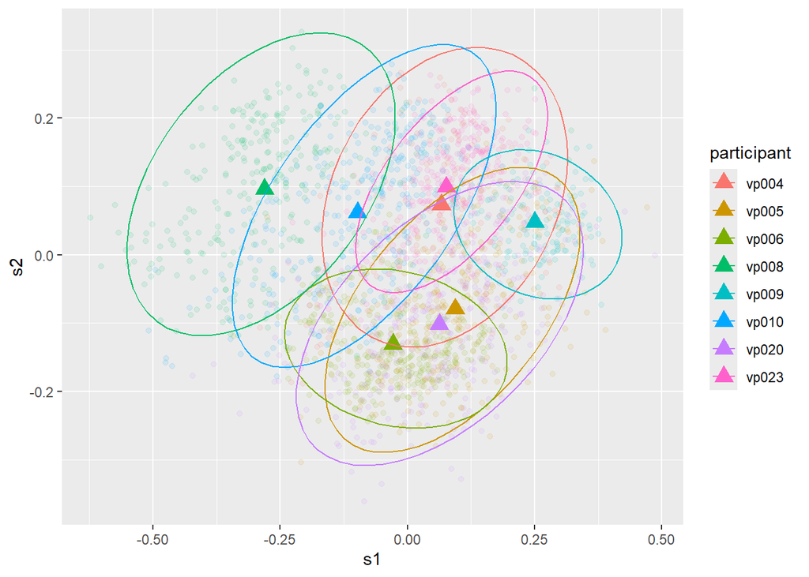

```r
PCscores_static_polar_scatterplot
```

The participants vary a lot in the PC1 score (s1). While participant 8 has the lowest s1, participant 9 has the highest. The other participants are somewhere inbetween but rather close together with participant 6 and 10 having scores lower than the mean (0) and participants 4, 5, 20 and 23 having scores higher than the mean. As we know from the plot above, s1 describes a retraction/fronting and a lowering/raising of the tongue tip. Participant 8 and the other participants showing a rather low s1 should therefore have a predicted tongue contour that is fronted and has a raised tongue tip (what could be a hint for alveolar/front rhotics), while participant 9 and the participants having a rather high s1 should have a predicted tongue contour that is retracted and has a downwards pointing tongue tip (what could be a hint for uvular/back rhotics).

For the PC2 score (s2), there seem to be two groups of participants: participants 5, 6 and 20 have a low s2, while the other participants (4, 8, 9, 10 and 23) have a rather high s2. There isn’t a clean cut between those two groups but when looking at the mean scores, it becomes evident that there is a split (although the data points overlap partially). Looking back at the plots showing the variation covered through the PC2 score, we know that s2 describes the “steepness” of the tongue shape. A low s2 (such as that of participants 5, 6 and 20) describes a higher tongue dorsum/steeper tongue shape and a high s2 (such as that of participants 4, 8, 9, 10 and 23) describes a flatter tongue shape.

Now we’re interested in calculating a linear model (lm) to see if the PC scores correlate with the variable `participant` (`lm(PCscore ~ participant)`) or if this is just random. Can we predict s1/s2 by participant?

```r
# s1
s1_mod <- lm(s1 ~ participant, data = PCscores_static_polar)
s1_mod %>% summary()
```

```
##
## Call:
## lm(formula = s1 ~ participant, data = PCscores_static_polar)
##
## Residuals:
##      Min       1Q   Median       3Q      Max
## -0.48538 -0.06883  0.00736  0.07203  0.60290
##
## Coefficients:
##                   Estimate Std. Error t value Pr(>|t|)
## (Intercept)       0.066672   0.009424   7.075 2.02e-12 ***
## participantvp005  0.027323   0.011511   2.374   0.0177 *
## participantvp006 -0.095077   0.011493  -8.273 2.26e-16 ***
## participantvp008 -0.347636   0.011614 -29.933  < 2e-16 ***
## participantvp009  0.183762   0.013284  13.833  < 2e-16 ***
## participantvp010 -0.164971   0.011493 -14.355  < 2e-16 ***
## participantvp020 -0.003784   0.011469  -0.330   0.7415
## participantvp023  0.009848   0.011481   0.858   0.3911
## ---
## Signif. codes:  0 '***' 0.001 '**' 0.01 '*' 0.05 '.' 0.1 ' ' 1
##
## Residual standard error: 0.1162 on 2154 degrees of freedom
## Multiple R-squared:  0.594,  Adjusted R-squared:  0.5927
## F-statistic: 450.3 on 7 and 2154 DF,  p-value: < 2.2e-16
```

```r
emmeans(s1_mod, pairwise ~ participant)
```

```
## $emmeans
##  participant  emmean      SE   df lower.CL upper.CL
##  vp004        0.0667 0.00942 2154   0.0482   0.0852
##  vp005        0.0940 0.00661 2154   0.0810   0.1070
##  vp006       -0.0284 0.00658 2154  -0.0413  -0.0155
##  vp008       -0.2810 0.00679 2154  -0.2943  -0.2677
##  vp009        0.2504 0.00936 2154   0.2321   0.2688
##  vp010       -0.0983 0.00658 2154  -0.1112  -0.0854
##  vp020        0.0629 0.00654 2154   0.0501   0.0757
##  vp023        0.0765 0.00656 2154   0.0637   0.0894
##
## Confidence level used: 0.95
##
## $contrasts
##  contrast      estimate      SE   df t.ratio p.value
##  vp004 - vp005 -0.02732 0.01150 2154  -2.374  0.2548
##  vp004 - vp006  0.09508 0.01150 2154   8.273  <.0001
##  vp004 - vp008  0.34764 0.01160 2154  29.933  <.0001
##  vp004 - vp009 -0.18376 0.01330 2154 -13.833  <.0001
##  vp004 - vp010  0.16497 0.01150 2154  14.355  <.0001
##  vp004 - vp020  0.00378 0.01150 2154   0.330  1.0000
##  vp004 - vp023 -0.00985 0.01150 2154  -0.858  0.9896
##  vp005 - vp006  0.12240 0.00932 2154  13.126  <.0001
##  vp005 - vp008  0.37496 0.00947 2154  39.577  <.0001
##  vp005 - vp009 -0.15644 0.01150 2154 -13.650  <.0001
##  vp005 - vp010  0.19229 0.00932 2154  20.622  <.0001
##  vp005 - vp020  0.03111 0.00930 2154   3.346  0.0189
##  vp005 - vp023  0.01748 0.00931 2154   1.877  0.5669
##  vp006 - vp008  0.25256 0.00945 2154  26.720  <.0001
##  vp006 - vp009 -0.27884 0.01140 2154 -24.369  <.0001
##  vp006 - vp010  0.06989 0.00930 2154   7.514  <.0001
##  vp006 - vp020 -0.09129 0.00927 2154  -9.845  <.0001
##  vp006 - vp023 -0.10492 0.00929 2154 -11.297  <.0001
##  vp008 - vp009 -0.53140 0.01160 2154 -45.952  <.0001
##  vp008 - vp010 -0.18267 0.00945 2154 -19.326  <.0001
##  vp008 - vp020 -0.34385 0.00942 2154 -36.491  <.0001
##  vp008 - vp023 -0.35748 0.00944 2154 -37.880  <.0001
##  vp009 - vp010  0.34873 0.01140 2154  30.478  <.0001
##  vp009 - vp020  0.18755 0.01140 2154  16.425  <.0001
##  vp009 - vp023  0.17391 0.01140 2154  15.215  <.0001
##  vp010 - vp020 -0.16119 0.00927 2154 -17.383  <.0001
##  vp010 - vp023 -0.17482 0.00929 2154 -18.823  <.0001
##  vp020 - vp023 -0.01363 0.00926 2154  -1.472  0.8222
##
## P value adjustment: tukey method for comparing a family of 8 estimates
```

Now we should be able to reconstruct the tongue contours that are predicted by s1 for each participant:

```r
# reconstruct predicted curves
predCurves_s1 <- emmeans(s1_mod, pairwise ~ participant)$emmeans %>%
  as_tibble() %>%
  group_by(participant) %>%
  reframe(bind_cols(
    funData2long1(fpca_polar_static_proc$mu + emmean * fpca_polar_static_proc$functions[1], time = 'angle', value = "radius"),
    funData2long1(fpca_polar_static_proc$mu + lower.CL * fpca_polar_static_proc$functions[1], time = 'angle', value = "yl") %>%
      select(yl),
    funData2long1(fpca_polar_static_proc$mu + upper.CL * fpca_polar_static_proc$functions[1], time = 'angle', value = "yu") %>%
      select(yu)
  ))

FPCA_static_polar_predplot_s1 <- ggplot(predCurves_s1) +
  aes(angle, radius, color = participant) +
  geom_line() +
  geom_ribbon(aes(x = angle, ymin = yl, ymax = yu, fill = participant),
              alpha = 0.3, inherit.aes = FALSE) +
  radial_plot(5) +
  theme(legend.position = "bottom")
```

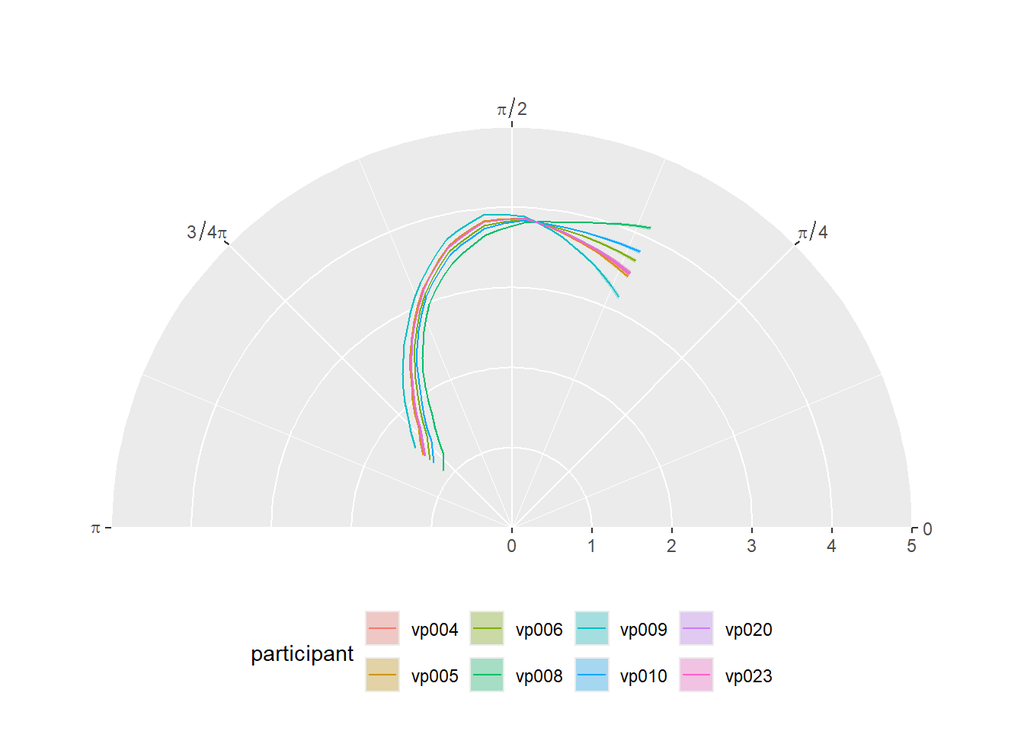

```r
FPCA_static_polar_predplot_s1
```

In this prediction plot, we can see the wide range of tongue contours that the lm predicted based on the participants’ PC1 scores. As expected, participant 9 has the most retracted tongue contour with the most downwards pointing tongue tip while participant 8 has the most fronted tongue contour with a raised tongue tip.

We can do the same type of model for s2:

```r
# s2
s2_mod <- lm(s2 ~ participant, data = PCscores_static_polar)
s2_mod %>% summary()
```

```
##
## Call:
## lm(formula = s2 ~ participant, data = PCscores_static_polar)
##
## Residuals:
##       Min        1Q    Median        3Q       Max
## -0.261680 -0.059538  0.003332  0.060859  0.258597
##
## Coefficients:
##                   Estimate Std. Error t value Pr(>|t|)
## (Intercept)       0.073047   0.007154  10.210  < 2e-16 ***
## participantvp005 -0.152292   0.008738 -17.428  < 2e-16 ***
## participantvp006 -0.203836   0.008724 -23.364  < 2e-16 ***
## participantvp008  0.023014   0.008817   2.610  0.00911 **
## participantvp009 -0.025314   0.010085  -2.510  0.01214 *
## participantvp010 -0.010983   0.008724  -1.259  0.20819
## participantvp020 -0.174912   0.008706 -20.090  < 2e-16 ***
## participantvp023  0.026159   0.008715   3.002  0.00272 **
## ---
## Signif. codes:  0 '***' 0.001 '**' 0.01 '*' 0.05 '.' 0.1 ' ' 1
##
## Residual standard error: 0.0882 on 2154 degrees of freedom
## Multiple R-squared:  0.5276, Adjusted R-squared:  0.526
## F-statistic: 343.6 on 7 and 2154 DF,  p-value: < 2.2e-16
```

```r
emmeans(s2_mod, pairwise ~ participant)
```

```
## $emmeans
##  participant  emmean      SE   df lower.CL upper.CL
##  vp004        0.0730 0.00715 2154   0.0590   0.0871
##  vp005       -0.0792 0.00502 2154  -0.0891  -0.0694
##  vp006       -0.1308 0.00499 2154  -0.1406  -0.1210
##  vp008        0.0961 0.00515 2154   0.0860   0.1062
##  vp009        0.0477 0.00711 2154   0.0338   0.0617
##  vp010        0.0621 0.00499 2154   0.0523   0.0719
##  vp020       -0.1019 0.00496 2154  -0.1116  -0.0921
##  vp023        0.0992 0.00498 2154   0.0894   0.1090
##
## Confidence level used: 0.95
##
## $contrasts
##  contrast      estimate      SE   df t.ratio p.value
##  vp004 - vp005  0.15229 0.00874 2154  17.428  <.0001
##  vp004 - vp006  0.20384 0.00872 2154  23.364  <.0001
##  vp004 - vp008 -0.02301 0.00882 2154  -2.610  0.1526
##  vp004 - vp009  0.02531 0.01010 2154   2.510  0.1915
##  vp004 - vp010  0.01098 0.00872 2154   1.259  0.9137
##  vp004 - vp020  0.17491 0.00871 2154  20.090  <.0001
##  vp004 - vp023 -0.02616 0.00872 2154  -3.002  0.0549
##  vp005 - vp006  0.05154 0.00708 2154   7.281  <.0001
##  vp005 - vp008 -0.17531 0.00719 2154 -24.374  <.0001
##  vp005 - vp009 -0.12698 0.00870 2154 -14.595  <.0001
##  vp005 - vp010 -0.14131 0.00708 2154 -19.962  <.0001
##  vp005 - vp020  0.02262 0.00706 2154   3.206  0.0297
##  vp005 - vp023 -0.17845 0.00707 2154 -25.249  <.0001
##  vp006 - vp008 -0.22685 0.00718 2154 -31.615  <.0001
##  vp006 - vp009 -0.17852 0.00869 2154 -20.552  <.0001
##  vp006 - vp010 -0.19285 0.00706 2154 -27.309  <.0001
##  vp006 - vp020 -0.02892 0.00704 2154  -4.109  0.0011
##  vp006 - vp023 -0.22999 0.00705 2154 -32.621  <.0001
##  vp008 - vp009  0.04833 0.00878 2154   5.505  <.0001
##  vp008 - vp010  0.03400 0.00718 2154   4.738  0.0001
##  vp008 - vp020  0.19793 0.00715 2154  27.669  <.0001
##  vp008 - vp023 -0.00315 0.00716 2154  -0.439  0.9999
##  vp009 - vp010 -0.01433 0.00869 2154  -1.650  0.7196
##  vp009 - vp020  0.14960 0.00867 2154  17.258  <.0001
##  vp009 - vp023 -0.05147 0.00868 2154  -5.932  <.0001
##  vp010 - vp020  0.16393 0.00704 2154  23.287  <.0001
##  vp010 - vp023 -0.03714 0.00705 2154  -5.268  <.0001
##  vp020 - vp023 -0.20107 0.00703 2154 -28.610  <.0001
##
## P value adjustment: tukey method for comparing a family of 8 estimates
```

```r
# reconstruct predicted curves
predCurves_s2 <- emmeans(s2_mod, pairwise ~ participant)$emmeans %>%
  as_tibble() %>%
  group_by(participant) %>%
  reframe(bind_cols(
    funData2long1(fpca_polar_static_proc$mu + emmean * fpca_polar_static_proc$functions[2], time = 'angle', value = "radius"),
    funData2long1(fpca_polar_static_proc$mu + lower.CL * fpca_polar_static_proc$functions[2], time = 'angle', value = "yl") %>%
      select(yl),
    funData2long1(fpca_polar_static_proc$mu + upper.CL * fpca_polar_static_proc$functions[2], time = 'angle', value = "yu") %>%
      select(yu)
  ))

FPCA_static_polar_predplot_s2 <- ggplot(predCurves_s2) +
  aes(angle, radius, color = participant) +
  geom_line() +
  geom_ribbon(aes(x = angle, ymin = yl, ymax = yu, fill = participant),
              alpha = 0.3, inherit.aes = FALSE) +
  radial_plot(5) +
  theme(legend.position = "bottom")
```

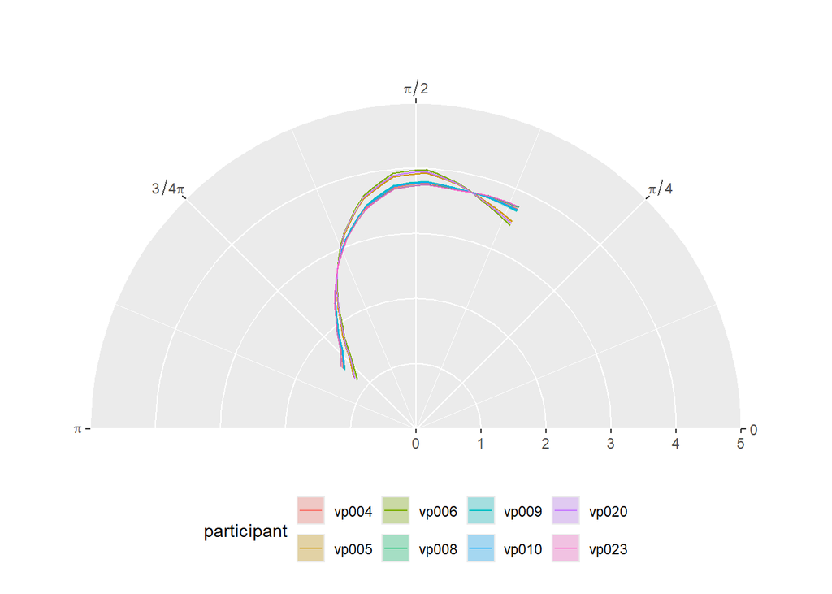

```r
FPCA_static_polar_predplot_s2
```

#### cartesian coordinates

We want to predict the splines on the basis of the 11 knots. To make more fine-grained predictions and plots, we add artificial “extra knots” between the original knots. We first want to create a grid for the prediction.

```r
sampling_period <- 0.1
maxknot <- max(rhotic_data_static$knot)
grid <- seq(0, maxknot, by = sampling_period)
```

We now need to make the data longer and create two separate columns: One column called “dim” that tells us the dimension of the value (either X-axis or Y-axis) and one column called “value” with the position of the sensor on the respective axis/dimension.

```r
curves_xy <- rhotic_data_static %>%
  pivot_longer(cols = c(x_mean_z, y_mean_z), names_to = "dim", values_to = "value") %>%
  group_by(filename, frame_id, participant, stress, type, vowel_place, consonant_place, dim) %>%
  reframe(approx(knot, value, grid, rule = 2) %>% as_tibble()) %>%
  ungroup() %>% rename(knot = x, value = y)
```

The next step is to build a `multiFunData` object (from the funData package), what is a class for multivariate functional data. We use the `long2irregFunData` function from the `landmarkregUtils` package to convert our data to the correct data object.

```r
# build a multiFunData object
curvesFun2D <- lapply(c("x_mean_z", "y_mean_z"), function(y)
  long2irregFunData(curves_xy %>% filter(dim == {{y}}),
                    id = "frame_id",
                    time = "knot",
                    value = "value") %>%
    as.funData()
) %>%
  multiFunData()
```

Now we have the curvesFun2D object that we need to compute the FPCA.

We will now compute 5 Principle Components - that’s more than we actually need. This is “a quick way to get a good approx for the % explained var per PC” (source: UTI analysis tutorial by Michele Gubian)

```r
# Compute FPCA
nPC <- 5
mfpca <- MFPCA(curvesFun2D,
               M = nPC,
               uniExpansions = list(list(type = "uFPCA"),list(type = "uFPCA"))
)

# Prop of explained var
PropExpVar <- round(mfpca$values / sum( mfpca$values) , digits = 3)
# scores st dev
sdFun <- mfpca$values %>% sqrt()

PropExpVar
```

```
## [1] 0.539 0.262 0.100 0.062 0.037
```

The 1st PC explains about 54 % of the variance of the data, the 2nd PC explains 26 % and the 3rd still explains at least 10 % of the variance.

Going further, we will use the first two PCs and plot the according curves.

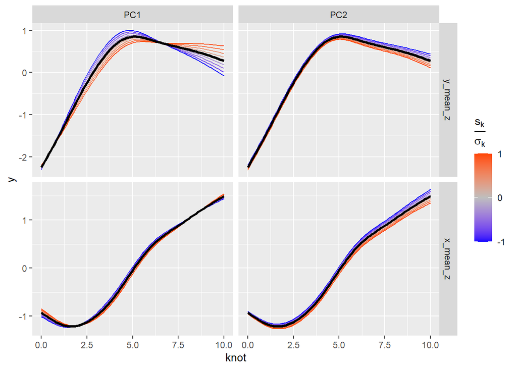

```r
nPC <- 2
# PC curves to be plotted
PCcurves_xy <- expand_grid(PC = 1:nPC,
                        dim = 1:2,
                        fractionOfStDev = seq(-1, 1, by=.25)) %>%
  group_by(PC, dim, fractionOfStDev) %>%
  reframe(
    funData2long1(
      mfpca$meanFunction[[dim]] +
        fractionOfStDev * sdFun[PC] * mfpca$functions[[dim]][PC],
      time= "knot", value = "y")
  ) %>%
  mutate(dim = factor(dim, levels = c(2,1), labels = c('y_mean_z', 'x_mean_z')))

# Plot
FPCA_2PCs_plot <- ggplot(PCcurves_xy) +
  aes(x = knot, y = y, group = fractionOfStDev, color = fractionOfStDev) +
  geom_line() +
  scale_color_gradient2(low = "blue", mid = "grey", high = "orangered",
                        breaks = c(-1, 0 , 1)) +
  facet_grid(dim ~ PC,
             scales = "free_y",
             labeller = labeller(PC = ~ str_glue("PC{.x}"))) + #,
                                 # dim = dimlabels)) +
  labs(color = expression(frac(s[k], sigma[k]))) +
  geom_line(data = PCcurves_xy %>% filter(fractionOfStDev == 0), color = 'black', linewidth = 1.2)

FPCA_2PCs_plot
```

On the left side, the results of PC1 are pictured, PC2 is pictured on the right side. In the top row, the y-value (tongue movement from bottom to the top of the mouth) is pictured on the y-axis, in the bottom row, the x-values are pictured on the y-axis (tongue movement from back/posterior [small x-value] to front/anterior [large x-value]). The x-axis shows the 11 knots of the tongue spline (most posterior knot = 0; most anterior knot = 10).

We can observe that PC1 mainly describes a movement in the y-axis, both in the back region of the graph/tongue (around knot 2 to 5) and the front of the tongue (around knot 7 to 10). A higher PC1 score changes the back part of the tongue to be lower (= lower y-value) and a lower PC1 score changes the back part to be higher (= higher y-value). It also has an influence on the tongue tip (knot 7 to 10): the lower the PC1 score is, the lower the tongue tip is - the higher PC1 is, the higher the tongue tip is. On the x-axis, PC1 influences the graph to be a *bit* more advanced or more retracted, nearly in its entirety (~knot 2 to 8). The higher the PC1 score is, the lower is the value of the knots on the x-axis and the more fronted is the graph compared to the mean. This means that the tongue is more posterior (further back) if the PC1 score is higher; and more anterior (more fronted) if the PC1 score is lower. Interestingly, the opposite is true for the back and front part of the tongue (knot 0 to 2 and knot 9 to 10) - here, the tongue is more posterior (further back) if the PC1 score is lower and more anterior (more fronted) if the PC2 score is higher. Anyways, these movements are rather small compared to the movements on the y-axis.

When we think about the rhotics that we are investigating, the PC1 score shows us a difference of tongue height around the uvular (knot 3 to 7) as well as the alveolar (knot 8 to 10) region. A higher PC1 score may tell us that the tongue is further away from the palate in the uvular region, a lower PC1 may be an indicator that the tongue is approaching the palate. For the alveolar region, a low PC1 score describes a bunched rhotic with the tongue tip pointing downwards while a high PC1 score describes the tongue tip as pointing upwards.

We would suspect that uvular fricatives have a low PC1 score because the tongue should be close to the uvular region of the palate while articulating uvular fricatives. Uvular approximants should have a low PC1 score as well, but not as low as the fricatives. Alveolar rhotics should have a high PC1 score, because they are not articulated with an approach of the tongue to the uvular. Instead they have a raised tongue tip what is the case for a high PC1 score.

PC2 mainly describes a movement of the knots 5 to 10, so the front part of the tongue. A low PC2 score causes a higher y-value and a slightly higher x-value in the front part of the mouth, a high PC2 score causes a lower y-value and a slightly lower x-value. This means the tongue tip is raised and slightly more anterior (fronted) for a low PC2 and the tongue tip is pointed downwards and slightly more retracted for a higher PC2.

When thinking of the rhotics we would expect uvular rhotics to have a higher PC2 score, because for uvular rhotics the tongue tip goes downwards and the tongue tip might be retracted. For alveolar rhotics we expect a low PC2 score because the tongue tip is typically raised and the tongue might be a bit fronted.